# Empathic-dynamics: Full Analyses

Author

SSK

# Set-up

```r
library(tidyverse)
library(psych)
library(knitr)
library(report)
library(ggpubr)
library(sjPlot)
```

```r
theme_perez <- function() {
    ggplot2::theme_bw() +
    ggplot2::theme(
      axis.text = element_text(colour = "black",  family = "Times New Roman", size = 12),
    axis.title = element_text(colour = "black", family = "Times New Roman", size = 13),
    legend.title = element_text(colour = "black", family = "Times New Roman", size = 13),
    legend.text = element_text(colour = "black", family = "Times New Roman", size = 12),
    plot.title = element_text(colour = "black", family = "Times New Roman", size = 13),
    plot.subtitle = element_text(colour = "black", family = "Times New Roman", size = 13),
    strip.text = element_text(colour = "black", family = "Times New Roman", size = 13))
}

horzi_theme <- theme(    #   remove the gray background
  panel.background    = element_rect( size=.1, colour="black", fill="white") ,
  #   make the major gridlines light gray and thin
  panel.grid.major.y  = element_line( size=.1, colour="#666666" ) ,
  #   suppress the vertical grid lines
  panel.grid.major.x  = element_blank() ,
  #   suppress the minor grid lines
  panel.grid.minor    = element_blank() ,
  #   add axes
  axis.line           = element_line( size=.2 , colour="#666666" ),
  #   adjust the axis ticks
  axis.ticks          = element_line( size=.1 , colour="#666666" ),
  #   move the y-axis over to the left
  #axis.title.y        = element_text( angle=90, vjust=.5, hjust=.5 ),
  #   increase margin moved-over y-axis label fits
  # plot.margin = unit( c(.5,.25,.25,.5) , "in") ,
  title = element_text(  size=12 ) ,
  axis.title.x = element_text( size=12 ) ,
  axis.title.y = element_text( size=12 ) ,
  axis.text.x = element_text( size=12 ) ,
  axis.text.y = element_text( size=12 )
)

horzi <- horzi_theme

stat_sum_df <- function(fun, geom="crossbar", ...) {
  stat_summary(fun.data=fun, colour="black", geom=geom, width=.5,  ...)
}

# define the dodge object for equivalent error bar and geom_bar
dodge <- position_dodge(width=0.9)

# define a geom_bar
bars <- geom_bar(stat="summary", fun.y="mean", position="dodge")
```

```r
data <- read.csv("clean_fulldata_20240910.csv")
```

# High-Level Findings

**Confirmatory**

- Treatment had a significant effect on **multiple-selves / complexity beliefs**
- Treatment had a significant effect on **relationship-prioritization** and **perspective-taking**

**Exploratory**

- Treatment had a marginal effect on **perspective-taking** for manager scenario

**Session 2**

# Key

| Symbol | Sig. Level | p |
| --- | --- | --- |
| 🟢 | Significant | < 0.05 |
| ️️🟡 | Marginal / Trending | 0.05 - 0.09 |
| 🔴 | Non-Significant | > 0.10 |

# Session 1

# Descriptives

**Condition**

```r
kable(data %>%
  filter(!is.na(Condition)) %>%
  group_by(Condition) %>%
  summarise("n" = n(),
            "%" = ((n() / nrow(data)) * 100)))
```

| Condition | n | % |
| --- | --- | --- |
| Control | 103 | 47.90698 |
| Treatment | 105 | 48.83721 |

**School / Division**

```r
kable(table(data$schoolDivision), col.names = c("School / Division","Freq"))
```

| School / Division | Freq |
| --- | --- |
| Athletics | 2 |
| Education | 4 |
| Goldman | 5 |
| Haas | 39 |
| Law | 39 |
| Social Welfare | 5 |
| Student Affairs | 82 |
| UDAR | 32 |

**Academic / Staff**

```r
kable(data %>%
  group_by(academic) %>%
  summarise("n" = n(),
            "%" = ((n() / nrow(data)) * 100)))
```

| academic | n | % |
| --- | --- | --- |
| Academic | 7 | 3.255814 |
| Staff | 199 | 92.558139 |
| NA | 9 | 4.186046 |

**Manager**

```r
kable(data %>%
  filter(yearsWork != 2013.00) %>%
  summarise(mean = mean(yearsWork),
            sd = sd(yearsWork),
            min = min(yearsWork),
            max = max(yearsWork)))
```

| mean | sd | min | max |
| --- | --- | --- | --- |
| 4.558642 | 5.376763 | -1 | 35.5 |

```r
kable(table(data$manager), col.names = c("Manager","Freq"))
```

| Manager | Freq |
| --- | --- |
| No | 121 |
| Yes | 86 |

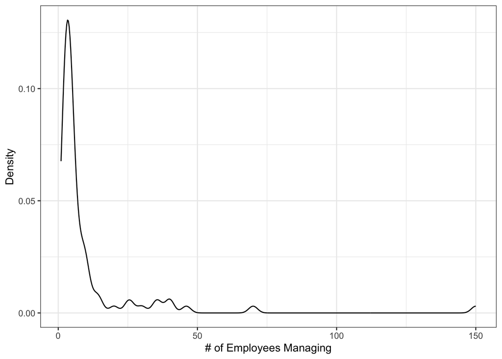

```r
ggplot(data, aes(x=managerHowMany)) +
  geom_density() +
  labs(x = "# of Employees Managing",
       y = "Density") +
  theme_bw()
```

```r
kable(psych::describe(data$managerHowMany), row.names = F)
```

| vars | n | mean | sd | median | trimmed | mad | min | max | range | skew | kurtosis | se |
| --- | --- | --- | --- | --- | --- | --- | --- | --- | --- | --- | --- | --- |
| 1 | 82 | 10.45732 | 19.61295 | 4 | 6.037879 | 2.9652 | 1 | 150 | 149 | 4.930049 | 29.64232 | 2.165888 |

**Gender**

```r
kable(data %>%
  group_by(gender) %>%
  summarise("n" = n(),
            "%" = ((n() / nrow(data)) * 100)))
```

| gender | n | % |
| --- | --- | --- |
| Female | 136 | 63.2558140 |
| Genderqueer or Nonbinary Gender | 17 | 7.9069767 |
| Male | 54 | 25.1162791 |
| Trans Male / Trans Man | 1 | 0.4651163 |
| NA | 7 | 3.2558140 |

**Race**

```r
kable(data %>%
  group_by(race) %>%
  summarise("n" = n(),
            "%" = ((n() / nrow(data)) * 100)))
```

| race | n | % |
| --- | --- | --- |
| African American / Black | 7 | 3.2558140 |
| American Indian / Alaskan Native | 2 | 0.9302326 |
| Chinese | 12 | 5.5813953 |
| Filipino | 6 | 2.7906977 |
| Hispanic / Latino | 26 | 12.0930233 |
| Japanese | 1 | 0.4651163 |
| Korean | 3 | 1.3953488 |
| Middle Eastern / Southwest Asian / North African (SWANA) | 3 | 1.3953488 |
| Other Asian | 3 | 1.3953488 |
| Pacific Islander | 1 | 0.4651163 |
| South Asian | 1 | 0.4651163 |
| Two or more races | 20 | 9.3023256 |
| White | 122 | 56.7441860 |
| NA | 8 | 3.7209302 |

**SES**

```r
kable(data %>%
  group_by(income) %>%
  summarise("n" = n(),
            "%" = ((n() / nrow(data)) * 100)))
```

| income | n | % |
| --- | --- | --- |
| $100,001 - $150,000 | 52 | 24.1860465 |
| $15,000 - $30,000 | 2 | 0.9302326 |
| $30,001 - $50,000 | 6 | 2.7906977 |
| $50,001 - $75,000 | 30 | 13.9534884 |
| $75,001 - $100,000 | 32 | 14.8837209 |
| greater than $150,000 | 85 | 39.5348837 |
| NA | 8 | 3.7209302 |

```r
kable(psych::describe(data$ladder), row.names = F)
```

| vars | n | mean | sd | median | trimmed | mad | min | max | range | skew | kurtosis | se |
| --- | --- | --- | --- | --- | --- | --- | --- | --- | --- | --- | --- | --- |
| 1 | 208 | 6.274038 | 1.620192 | 6 | 6.309524 | 1.4826 | 1 | 10 | 9 | -0.2622573 | -0.0171127 | 0.1123401 |

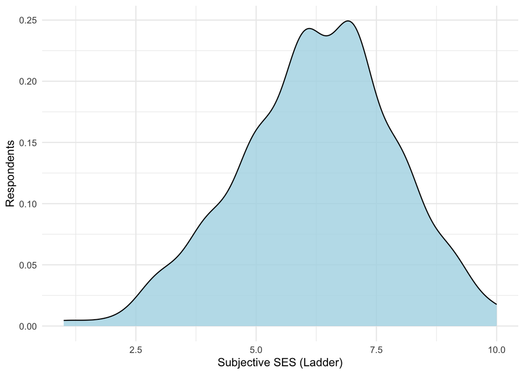

```r
ggplot(data, aes(ladder)) +
  geom_density(bins=20, fill="lightblue", alpha=0.8) +
  theme_minimal() +
  xlim(limits=c(1,10)) +
  labs(x = "Subjective SES (Ladder)",
       y = "Respondents")
```

# Confirmatory

**1. Relationship-prioritization 🟢**

*How likely are you to prioritize establishing a positive relationship with every single co-worker in your workplace?*

```r
kable(psych::describe(data$manipTreat1), row.names = F)
```

| vars | n | mean | sd | median | trimmed | mad | min | max | range | skew | kurtosis | se |
| --- | --- | --- | --- | --- | --- | --- | --- | --- | --- | --- | --- | --- |
| 1 | 125 | 5.112 | 1.71904 | 6 | 5.29703 | 1.4826 | 1 | 7 | 6 | -0.7107136 | -0.4911636 | 0.1537556 |

```r
tab_model(lm(manipTreat1 ~ Condition + wave, data))
```

|  | manipTreat1 |  |  |
| --- | --- | --- | --- |
| Predictors | Estimates | CI | p |
| (Intercept) | 4.18 | 3.26 – 5.11 | **<0.001** |
| Condition [Treatment] | 0.65 | 0.04 – 1.25 | **0.037** |
| wave | 0.44 | -0.18 – 1.05 | 0.164 |
| Observations | 124 |  |  |
| R<sup>2</sup> / R<sup>2</sup> adjusted | 0.057 / 0.042 |  |  |

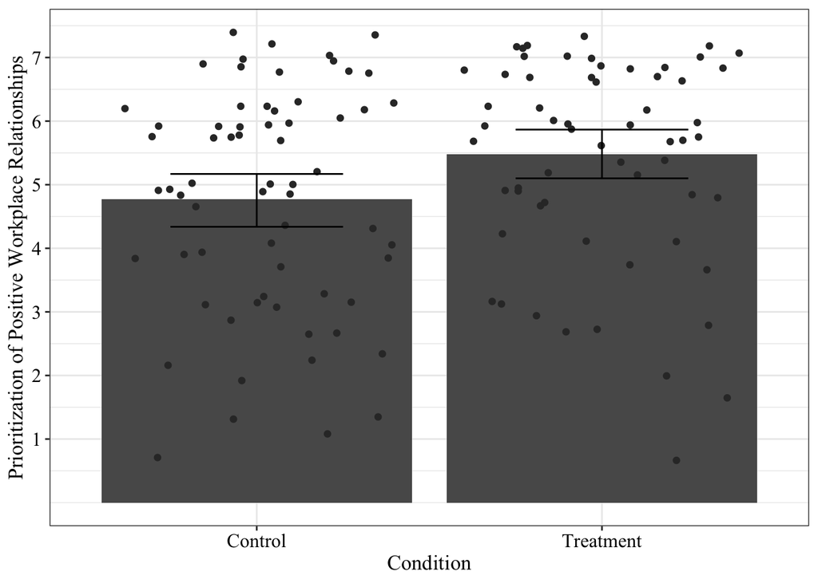

```r
# report::report(lm(manipTreat1 ~ Condition + wave, data))

plot1 <- data %>%
  filter(!is.na(Condition)) %>%
ggplot(aes(x=Condition, y=manipTreat1)) +
  geom_bar(stat="summary", position="dodge") +
  geom_jitter(color = "grey20") +
  stat_sum_df("mean_cl_boot", geom = "errorbar", position= position_dodge(.9), conf.int=.68, width=0.2) +
  expand_limits(y = c(1, 7)) +
  scale_y_continuous(breaks=c(1:7)) +
  theme_perez() +
  scale_fill_grey() +
  labs(y = "Prioritization of Positive Workplace Relationships")

plot1
```

**2. Multiple-selves / Complexity Beliefs 🟢**

*How much do you agree with the following statement?: Everyone in the workplace is complex inside and is capable of tapping into different parts of themself.*

| vars | n | mean | sd | median | trimmed | mad | min | max | range | skew | kurtosis | se |
| --- | --- | --- | --- | --- | --- | --- | --- | --- | --- | --- | --- | --- |
| 1 | 125 | 4.64 | 0.5875043 | 5 | 4.742574 | 0 | 3 | 5 | 2 | -1.378572 | 0.8476825 | 0.052548 |

|  | manipTreat2_recode |  |  |
| --- | --- | --- | --- |
| Predictors | Estimates | CI | p |
| (Intercept) | 4.55 | 4.24 – 4.87 | **<0.001** |
| Condition [Treatment] | 0.28 | 0.07 – 0.48 | **0.009** |
| wave | -0.03 | -0.25 – 0.18 | 0.749 |
| Observations | 124 |  |  |
| R<sup>2</sup> / R<sup>2</sup> adjusted | 0.054 / 0.039 |  |  |

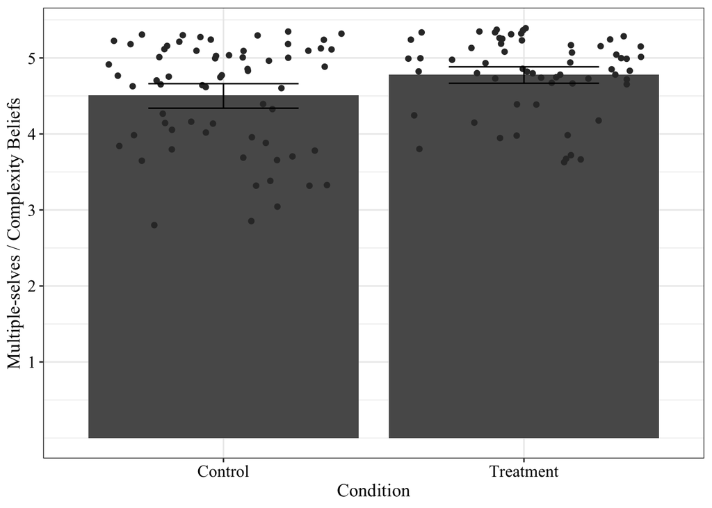

**3. Perspective-taking**

```r
perspectiveTaking <- data %>%
  dplyr::select(IRI_PT_1, IRI_PT_2, IRI_PT_3, IRI_PT_4)

kable(alpha(perspectiveTaking, na.rm=T, check.keys=T)$alpha)
```

|  | raw_alpha | std.alpha | G6(smc) | average_r | S/N | alpha se | var.r | med.r |
| --- | --- | --- | --- | --- | --- | --- | --- | --- |
| IRI_PT_1- | 0.6503871 | 0.6457601 | 0.5675601 | 0.3779735 | 1.8229457 | 0.0396950 | 0.0155420 | 0.3619463 |
| IRI_PT_2 | 0.5636560 | 0.5734016 | 0.5166223 | 0.3094121 | 1.3441250 | 0.0527032 | 0.0362379 | 0.2872651 |
| IRI_PT_3 | 0.5104451 | 0.5152199 | 0.4155329 | 0.2615914 | 1.0627911 | 0.0567394 | 0.0006723 | 0.2620947 |
| IRI_PT_4 | 0.4671646 | 0.4903306 | 0.4072188 | 0.2428174 | 0.9620564 | 0.0633990 | 0.0133646 | 0.2354143 |

$\alpha = 0.62$

**Per preregistration, will therefore look at items individually**

*Over the next 2 weeks while at work…*

**a. 🟢**

*I will try to look at everybody’s side of a disagreement before I make a decision.*

```r
tab_model(lm(IRI_PT_4 ~ Condition + wave, data))
```

|  | IRI_PT_4 |  |  |
| --- | --- | --- | --- |
| Predictors | Estimates | CI | p |
| (Intercept) | 4.02 | 3.58 – 4.46 | **<0.001** |
| Condition [Treatment] | 0.29 | 0.00 – 0.58 | **0.049** |
| wave | 0.09 | -0.20 – 0.38 | 0.548 |
| Observations | 124 |  |  |
| R<sup>2</sup> / R<sup>2</sup> adjusted | 0.038 / 0.022 |  |  |

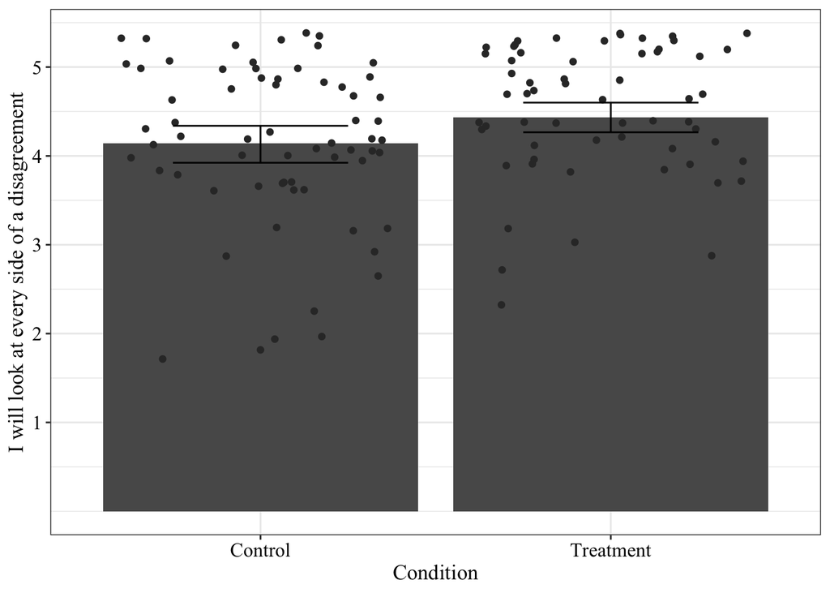

```r
# report::report(lm(IRI_PT_4 ~ Condition + wave, data))

plot3 <- data %>%
  filter(!is.na(Condition)) %>%
ggplot(aes(x=Condition, y=IRI_PT_4)) +
  geom_bar(stat="summary", position="dodge") +
  geom_jitter(color = "grey20") +
  stat_sum_df("mean_cl_boot", geom = "errorbar", position= position_dodge(.9), conf.int=.68, width=0.2) +
  expand_limits(y = c(1, 5)) +
  scale_y_continuous(breaks=c(1:5)) +
  theme_perez() +
  scale_fill_grey() +
  labs(y = "I will look at every side of a disagreement")

plot3
```

**b. 🟡**

*I will believe that there are two sides to every question and try to look at them both.*

```r
tab_model(lm(IRI_PT_3 ~ Condition + wave, data))
```

|  | IRI_PT_3 |  |  |
| --- | --- | --- | --- |
| Predictors | Estimates | CI | p |
| (Intercept) | 3.82 | 3.33 – 4.31 | **<0.001** |
| Condition [Treatment] | 0.30 | -0.02 – 0.62 | 0.062 |
| wave | 0.14 | -0.19 – 0.46 | 0.407 |
| Observations | 123 |  |  |
| R<sup>2</sup> / R<sup>2</sup> adjusted | 0.038 / 0.022 |  |  |

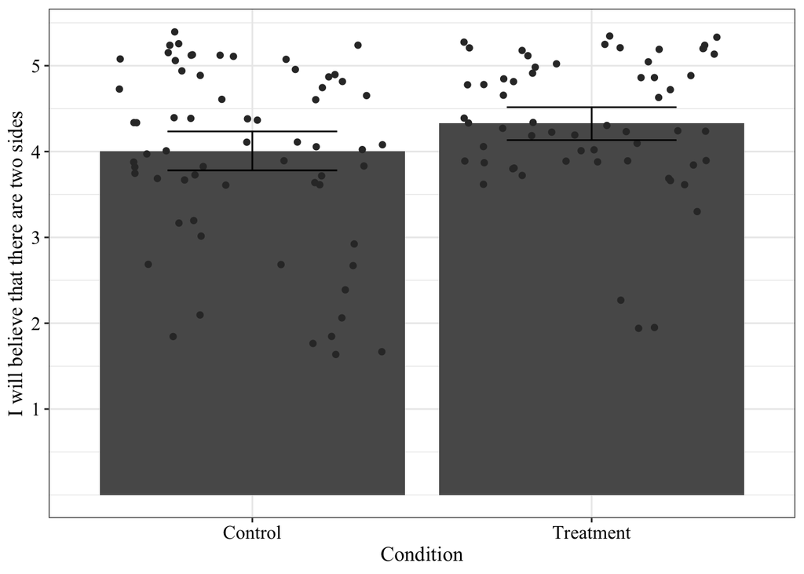

```r
# report::report(lm(IRI_PT_3 ~ Condition + wave, data))

plot4 <- data %>%
  filter(!is.na(Condition)) %>%
ggplot(aes(x=Condition, y=IRI_PT_3)) +
  geom_bar(stat="summary", position="dodge") +
  geom_jitter(color = "grey20") +
  stat_sum_df("mean_cl_boot", geom = "errorbar", position= position_dodge(.9), conf.int=.68, width=0.2) +
  expand_limits(y = c(1, 5)) +
  scale_y_continuous(breaks=c(1:5)) +
  theme_perez() +
  scale_fill_grey() +
  labs(y = "I will believe that there are two sides")

plot4
```

**c. 🔴**

*I will sometimes try to understand my coworkers better by imagining howthings look from their perspective.*

```r
tab_model(lm(IRI_PT_2 ~ Condition + wave, data))
```

|  | IRI_PT_2 |  |  |
| --- | --- | --- | --- |
| Predictors | Estimates | CI | p |
| (Intercept) | 4.32 | 3.94 – 4.70 | **<0.001** |
| Condition [Treatment] | 0.08 | -0.17 – 0.33 | 0.538 |
| wave | 0.02 | -0.23 – 0.27 | 0.878 |
| Observations | 123 |  |  |
| R<sup>2</sup> / R<sup>2</sup> adjusted | 0.004 / -0.013 |  |  |

**d. 🔴**

*if I’m sure I’m right about something, I won’t waste much time listening to other people’s arguments.*

```r
tab_model(lm(IRI_PT_1 ~ Condition + wave, data))
```

|  | IRI_PT_1 |  |  |
| --- | --- | --- | --- |
| Predictors | Estimates | CI | p |
| (Intercept) | 2.47 | 1.97 – 2.98 | **<0.001** |
| Condition [Treatment] | -0.16 | -0.49 – 0.17 | 0.337 |
| wave | -0.13 | -0.47 – 0.20 | 0.438 |
| Observations | 123 |  |  |
| R<sup>2</sup> / R<sup>2</sup> adjusted | 0.014 / -0.002 |  |  |

**Exploratory**

## Burnout 🔴

```r
tab_model(lm(burnout ~ Condition, data))
```

|  | burnout |  |  |
| --- | --- | --- | --- |
| Predictors | Estimates | CI | p |
| (Intercept) | 3.82 | 3.36 – 4.29 | **<0.001** |
| Condition [Treatment] | -0.02 | -0.70 – 0.65 | 0.945 |
| Observations | 96 |  |  |
| R<sup>2</sup> / R<sup>2</sup> adjusted | 0.000 / -0.011 |  |  |

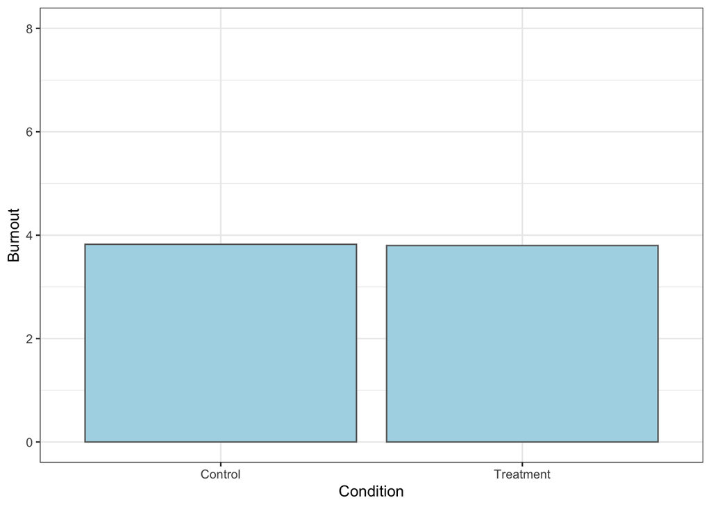

```r
data %>%
  filter(!is.na(Condition)) %>%
ggplot(aes(x=Condition, y=burnout)) +
  geom_bar(stat="summary", position="dodge", fill="lightblue", color = "grey40") +
  expand_limits(y = c(1, 8)) +
  theme_bw() +
  labs(y = "Burnout")
```

```r
kable(data %>%
  filter(!is.na(Condition), !is.na(burnout)) %>%
  group_by(Condition) %>%
  summarise(mean(burnout), sd(burnout)))
```

| Condition | mean(burnout) | sd(burnout) |
| --- | --- | --- |
| Control | 3.823529 | 1.424161 |
| Treatment | 3.800000 | 1.902152 |

## Scenario 1

**You just started a new role as a manager. You regularly try to meet with your new employees both as a team and one-on-one to get to know them and to give them the opportunity to get to know you. In general, you have built a good rapport with many of them and they seem to like your leadership style. However, after a few weeks, you notice that one of your employees has seemed to do the bare minimum with some work duties and doesn’t seem mentally present in meetings. From what you have heard, this employee tended to go above and beyond in their work before you started your new role.**

**Attributions 🔴**

```r
tab_model(lm(attributions_1 ~ Condition, data))
```

|  | attributions_1 |  |  |
| --- | --- | --- | --- |
| Predictors | Estimates | CI | p |
| (Intercept) | 3.38 | 3.18 – 3.57 | **<0.001** |
| Condition [Treatment] | 0.09 | -0.19 – 0.37 | 0.525 |
| Observations | 122 |  |  |
| R<sup>2</sup> / R<sup>2</sup> adjusted | 0.003 / -0.005 |  |  |

```r
kable(data %>%
  filter(!is.na(Condition), !is.na(attributions_1)) %>%
  group_by(Condition) %>%
  summarise(mean(attributions_1), sd(attributions_1)))
```

| Condition | mean(attributions_1) | sd(attributions_1) |
| --- | --- | --- |
| Control | 3.375000 | 0.8067178 |
| Treatment | 3.465517 | 0.7542980 |

**Perspective-Taking 🔴**

```r
tab_model(lm(IRI_PT1_1 ~ Condition, data))
```

|  | IRI_PT1_1 |  |  |
| --- | --- | --- | --- |
| Predictors | Estimates | CI | p |
| (Intercept) | 4.44 | 4.28 – 4.61 | **<0.001** |
| Condition [Treatment] | 0.09 | -0.15 – 0.33 | 0.464 |
| Observations | 123 |  |  |
| R<sup>2</sup> / R<sup>2</sup> adjusted | 0.004 / -0.004 |  |  |

```r
kable(data %>%
  filter(!is.na(Condition), !is.na(IRI_PT1_1)) %>%
  group_by(Condition) %>%
  summarise(mean(IRI_PT1_1), sd(IRI_PT1_1)))
```

| Condition | mean(IRI_PT1_1) | sd(IRI_PT1_1) |
| --- | --- | --- |
| Control | 4.444444 | 0.7356756 |
| Treatment | 4.533333 | 0.5956528 |

```r
tab_model(lm(IRI_PT2_1 ~ Condition, data))
```

|  | IRI_PT2_1 |  |  |
| --- | --- | --- | --- |
| Predictors | Estimates | CI | p |
| (Intercept) | 4.43 | 4.28 – 4.58 | **<0.001** |
| Condition [Treatment] | 0.07 | -0.14 – 0.29 | 0.515 |
| Observations | 123 |  |  |
| R<sup>2</sup> / R<sup>2</sup> adjusted | 0.004 / -0.005 |  |  |

```r
kable(data %>%
  filter(!is.na(Condition), !is.na(IRI_PT2_1)) %>%
  group_by(Condition) %>%
  summarise(mean(IRI_PT2_1), sd(IRI_PT2_1)))
```

| Condition | mean(IRI_PT2_1) | sd(IRI_PT2_1) |
| --- | --- | --- |
| Control | 4.428571 | 0.5878964 |
| Treatment | 4.500000 | 0.6243641 |

**Hard to Work With 🔴**

**How likely is it that you would find it hard to work with this employee at some point in the next month?**

```r
data <- data %>%
  mutate(hardToWorkWith_1 = case_match(hardToWorkWith_1,
                                         18 ~ 5,
                                         19 ~ 4,
                                         20 ~ 3,
                                         21 ~ 2,
                                         22 ~ 1))

tab_model(lm(hardToWorkWith_1 ~ Condition, data))
```

|  | hardToWorkWith_1 |  |  |
| --- | --- | --- | --- |
| Predictors | Estimates | CI | p |
| (Intercept) | 3.03 | 2.76 – 3.30 | **<0.001** |
| Condition [Treatment] | 0.07 | -0.31 – 0.45 | 0.719 |
| Observations | 122 |  |  |
| R<sup>2</sup> / R<sup>2</sup> adjusted | 0.001 / -0.007 |  |  |

```r
kable(data %>%
  filter(!is.na(Condition), !is.na(hardToWorkWith_1)) %>%
  group_by(Condition) %>%
  summarise(mean(hardToWorkWith_1), sd(hardToWorkWith_1)))
```

| Condition | mean(hardToWorkWith_1) | sd(hardToWorkWith_1) |
| --- | --- | --- |
| Control | 3.031746 | 1.092028 |
| Treatment | 3.101695 | 1.045432 |

**Valued 🟢**

**How likely is it that you would feel valued by this employee at some point in the next month?**

```r
tab_model(lm(valued_1_recode ~ Condition, data))
```

|  | valued_1_recode |  |  |
| --- | --- | --- | --- |
| Predictors | Estimates | CI | p |
| (Intercept) | 2.68 | 2.46 – 2.90 | **<0.001** |
| Condition [Treatment] | -0.41 | -0.73 – -0.09 | **0.012** |
| Observations | 122 |  |  |
| R<sup>2</sup> / R<sup>2</sup> adjusted | 0.051 / 0.043 |  |  |

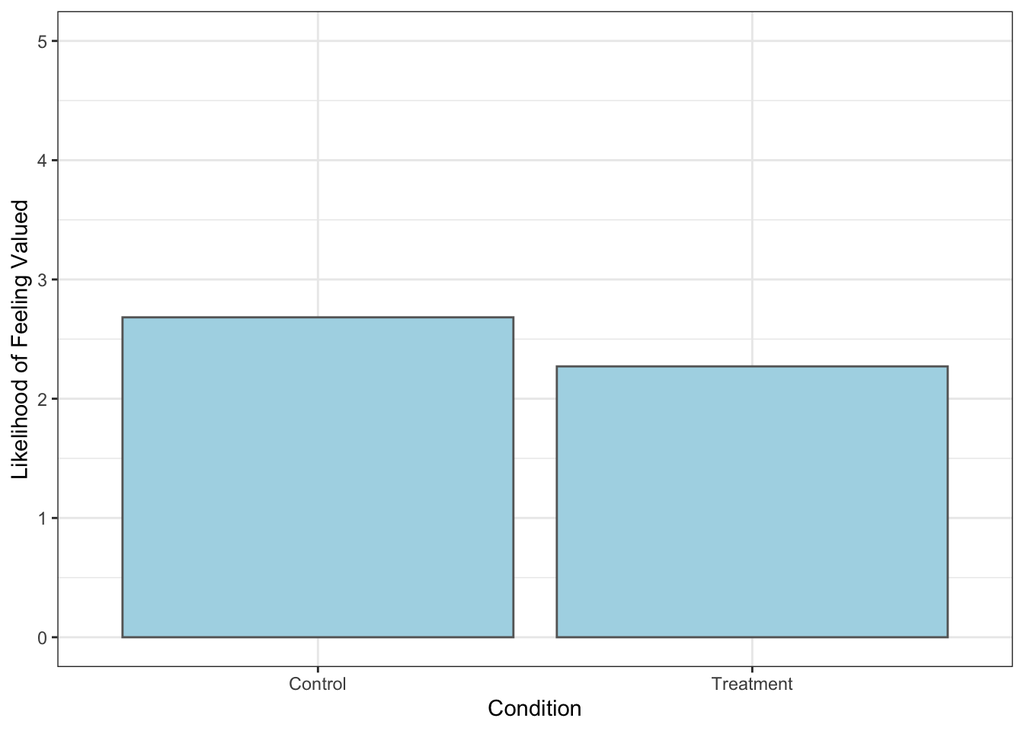

```r
data %>%
  filter(!is.na(Condition)) %>%
ggplot(aes(x=Condition, y=valued_1_recode)) +
  geom_bar(stat="summary", position="dodge", fill="lightblue", color = "grey40") +
  expand_limits(y = c(1, 5)) +
  theme_bw() +
  labs(y = "Likelihood of Feeling Valued")
```

```r
kable(data %>%
  filter(!is.na(Condition), !is.na(valued_1_recode)) %>%
  group_by(Condition) %>%
  summarise(mean(valued_1_recode), sd(valued_1_recode)))
```

| Condition | mean(valued_1_recode) | sd(valued_1_recode) |
| --- | --- | --- |
| Control | 2.682540 | 0.8948850 |
| Treatment | 2.271186 | 0.8872761 |

**360 🔴**

**I would be willing to give extensive feedback to this employee in a 360 assessment process.**

```r
data <- data %>%
  mutate(X360_1 = case_match(X360_1,
                                         1 ~ 5,
                                         2 ~ 4,
                                         3 ~ 3,
                                         4 ~ 2,
                                         5 ~ 1))

tab_model(lm(X360_1 ~ Condition, data))
```

|  | X360_1 |  |  |
| --- | --- | --- | --- |
| Predictors | Estimates | CI | p |
| (Intercept) | 3.75 | 3.49 – 4.01 | **<0.001** |
| Condition [Treatment] | 0.13 | -0.25 – 0.51 | 0.508 |
| Observations | 117 |  |  |
| R<sup>2</sup> / R<sup>2</sup> adjusted | 0.004 / -0.005 |  |  |

```r
kable(data %>%
  filter(!is.na(Condition), !is.na(X360_1)) %>%
  group_by(Condition) %>%
  summarise(mean(X360_1), sd(X360_1)))
```

| Condition | mean(X360_1) | sd(X360_1) |
| --- | --- | --- |
| Control | 3.750000 | 1.018889 |
| Treatment | 3.877193 | 1.053399 |

**Complaint 🔴**

**How likely is it that you would submit a formal complaint about this employee at some point?**

```r
data <- data %>%
  mutate(complaint_1 = case_match(complaint_1,
                                         1 ~ 5,
                                         2 ~ 4,
                                         3 ~ 3,
                                         4 ~ 2,
                                         5 ~ 1))

tab_model(lm(complaint_1 ~ Condition, data))
```

|  | complaint_1 |  |  |
| --- | --- | --- | --- |
| Predictors | Estimates | CI | p |
| (Intercept) | 1.82 | 1.63 – 2.00 | **<0.001** |
| Condition [Treatment] | 0.03 | -0.24 – 0.29 | 0.850 |
| Observations | 117 |  |  |
| R<sup>2</sup> / R<sup>2</sup> adjusted | 0.000 / -0.008 |  |  |

```r
kable(data %>%
  filter(!is.na(Condition), !is.na(complaint_1)) %>%
  group_by(Condition) %>%
  summarise(mean(complaint_1), sd(complaint_1)))
```

| Condition | mean(complaint_1) | sd(complaint_1) |
| --- | --- | --- |
| Control | 1.816667 | 0.6507275 |
| Treatment | 1.842105 | 0.7970811 |

## Scenario 2

**You just started reporting to a new manager. After a few weeks, you notice that the new manager has built rapport with some of your colleagues but hasn’t made much effort to get to know you. The new manager has several impromptu meetings per week and seems to forget to loop you in. Although you have been asked to pick up extra work, the manager doesn’t seem to acknowledge your effort or thank you for doing additional tasks.**

**Attributions 🔴**

```r
tab_model(lm(attributions_2 ~ Condition, data))
```

|  | attributions_2 |  |  |
| --- | --- | --- | --- |
| Predictors | Estimates | CI | p |
| (Intercept) | 2.44 | 2.21 – 2.67 | **<0.001** |
| Condition [Treatment] | 0.07 | -0.26 – 0.39 | 0.679 |
| Observations | 116 |  |  |
| R<sup>2</sup> / R<sup>2</sup> adjusted | 0.002 / -0.007 |  |  |

```r
kable(data %>%
  filter(!is.na(Condition), !is.na(attributions_2)) %>%
  group_by(Condition) %>%
  summarise(mean(attributions_2), sd(attributions_2)))
```

| Condition | mean(attributions_2) | sd(attributions_2) |
| --- | --- | --- |
| Control | 2.440678 | 0.8564398 |
| Treatment | 2.508772 | 0.9087434 |

**Perspective-Taking 🟡**

```r
tab_model(lm(IRI_PT1_2 ~ Condition, data))
```

|  | IRI_PT1_2 |  |  |
| --- | --- | --- | --- |
| Predictors | Estimates | CI | p |
| (Intercept) | 3.56 | 3.32 – 3.80 | **<0.001** |
| Condition [Treatment] | 0.30 | -0.04 – 0.65 | 0.084 |
| Observations | 117 |  |  |
| R<sup>2</sup> / R<sup>2</sup> adjusted | 0.026 / 0.017 |  |  |

```r
kable(data %>%
  filter(!is.na(Condition), !is.na(IRI_PT1_2)) %>%
  group_by(Condition) %>%
  summarise(mean(IRI_PT1_2), sd(IRI_PT1_2)))
```

| Condition | mean(IRI_PT1_2) | sd(IRI_PT1_2) |
| --- | --- | --- |
| Control | 3.559322 | 1.0548931 |
| Treatment | 3.862069 | 0.8045545 |

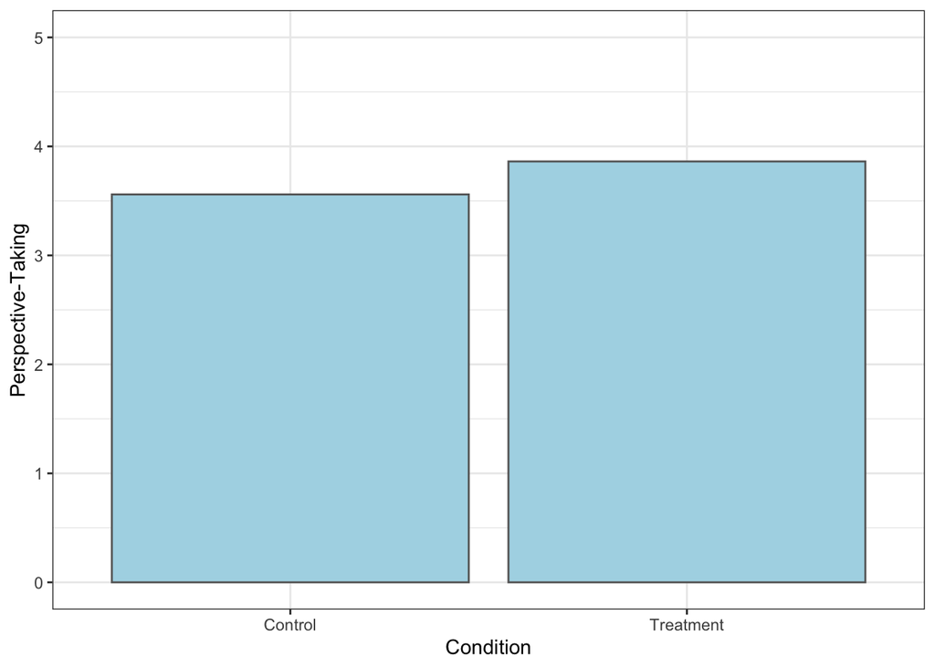

```r
data %>%
  filter(!is.na(Condition)) %>%
ggplot(aes(x=Condition, y=IRI_PT1_2)) +
  geom_bar(stat="summary", position="dodge", fill="lightblue", color = "grey40") +
  expand_limits(y = c(1, 5)) +
  theme_bw() +
  labs(y = "Perspective-Taking")
```

```r
tab_model(lm(IRI_PT2_2 ~ Condition, data))
```

|  | IRI_PT2_2 |  |  |
| --- | --- | --- | --- |
| Predictors | Estimates | CI | p |
| (Intercept) | 3.76 | 3.54 – 3.99 | **<0.001** |
| Condition [Treatment] | 0.19 | -0.13 – 0.50 | 0.247 |
| Observations | 117 |  |  |
| R<sup>2</sup> / R<sup>2</sup> adjusted | 0.012 / 0.003 |  |  |

```r
kable(data %>%
  filter(!is.na(Condition), !is.na(IRI_PT2_2)) %>%
  group_by(Condition) %>%
  summarise(mean(IRI_PT2_2), sd(IRI_PT2_2)))
```

| Condition | mean(IRI_PT2_2) | sd(IRI_PT2_2) |
| --- | --- | --- |
| Control | 3.762712 | 0.9161197 |
| Treatment | 3.948276 | 0.8039904 |

**360 🔴**

**I would be willing to give extensive feedback to this employee in a 360 assessment process.**

```r
data <- data %>%
  mutate(X360_2 = case_match(X360_2,
                                         1 ~ 5,
                                         2 ~ 4,
                                         3 ~ 3,
                                         4 ~ 2,
                                         5 ~ 1))

tab_model(lm(X360_2 ~ Condition, data))
```

|  | X360_2 |  |  |
| --- | --- | --- | --- |
| Predictors | Estimates | CI | p |
| (Intercept) | 2.29 | 1.99 – 2.60 | **<0.001** |
| Condition [Treatment] | 0.02 | -0.42 – 0.45 | 0.937 |
| Observations | 116 |  |  |
| R<sup>2</sup> / R<sup>2</sup> adjusted | 0.000 / -0.009 |  |  |

```r
kable(data %>%
  filter(!is.na(Condition), !is.na(X360_2)) %>%
  group_by(Condition) %>%
  summarise(mean(X360_2), sd(X360_2)))
```

| Condition | mean(X360_2) | sd(X360_2) |
| --- | --- | --- |
| Control | 2.293103 | 1.199541 |
| Treatment | 2.310345 | 1.157840 |

**Complaint 🔴**

**How likely is it that you would submit a formal complaint about this employee at some point?**

```r
data <- data %>%
  mutate(complaint_2 = case_match(complaint_2,
                                         1 ~ 5,
                                         2 ~ 4,
                                         3 ~ 3,
                                         4 ~ 2,
                                         5 ~ 1))

tab_model(lm(complaint_2 ~ Condition, data))
```

|  | complaint_2 |  |  |
| --- | --- | --- | --- |
| Predictors | Estimates | CI | p |
| (Intercept) | 2.09 | 1.81 – 2.37 | **<0.001** |
| Condition [Treatment] | -0.18 | -0.57 – 0.21 | 0.370 |
| Observations | 113 |  |  |
| R<sup>2</sup> / R<sup>2</sup> adjusted | 0.007 / -0.002 |  |  |

```r
kable(data %>%
  filter(!is.na(Condition), !is.na(complaint_2)) %>%
  group_by(Condition) %>%
  summarise(mean(complaint_2), sd(complaint_2)))
```

| Condition | mean(complaint_2) | sd(complaint_2) |
| --- | --- | --- |
| Control | 2.089286 | 1.1000295 |
| Treatment | 1.912281 | 0.9870718 |

**Engagement 🔴**

**I would be willing to put in extra effort if this manager asked me to.**

```r
data <- data %>%
  mutate(engagement = case_match(engagement,
                                         1 ~ 7,
                                         2 ~ 6,
                                         3 ~ 5,
                                         4 ~ 4,
                                         5 ~ 3,
                                         6 ~ 2,
                                         7 ~ 1))

tab_model(lm(engagement ~ Condition, data))
```

|  | engagement |  |  |
| --- | --- | --- | --- |
| Predictors | Estimates | CI | p |
| (Intercept) | 4.81 | 4.37 – 5.24 | **<0.001** |
| Condition [Treatment] | -0.18 | -0.80 – 0.44 | 0.563 |
| Observations | 113 |  |  |
| R<sup>2</sup> / R<sup>2</sup> adjusted | 0.003 / -0.006 |  |  |

```r
kable(data %>%
  filter(!is.na(Condition), !is.na(engagement)) %>%
  group_by(Condition) %>%
  summarise(mean(engagement), sd(engagement)))
```

| Condition | mean(engagement) | sd(engagement) |
| --- | --- | --- |
| Control | 4.807017 | 1.641413 |
| Treatment | 4.625000 | 1.690212 |

**Trust 🔴**

**How likely is it that you would trust this manager / the leader of your school, college, division or equivalent?**

```r
data <- data %>%
  mutate(trust_SOW_2 = case_match(trust_SOW_2,
                                         1 ~ 5,
                                         2 ~ 4,
                                         3 ~ 3,
                                         4 ~ 2,
                                         5 ~ 1))

tab_model(lm(trust_SOW_2 ~ Condition, data))
```

|  | trust_SOW_2 |  |  |
| --- | --- | --- | --- |
| Predictors | Estimates | CI | p |
| (Intercept) | 2.17 | 1.92 – 2.43 | **<0.001** |
| Condition [Treatment] | -0.09 | -0.45 – 0.27 | 0.636 |
| Observations | 116 |  |  |
| R<sup>2</sup> / R<sup>2</sup> adjusted | 0.002 / -0.007 |  |  |

```r
kable(data %>%
  filter(!is.na(Condition), !is.na(trust_SOW_2)) %>%
  group_by(Condition) %>%
  summarise(mean(trust_SOW_2), sd(trust_SOW_2)))
```

| Condition | mean(trust_SOW_2) | sd(trust_SOW_2) |
| --- | --- | --- |
| Control | 2.172414 | 0.9936276 |
| Treatment | 2.086207 | 0.9603450 |

```r
data <- data %>%
  mutate(trustLeader_SOW_2 = case_match(trustLeader_SOW_2,
                                         1 ~ 5,
                                         2 ~ 4,
                                         3 ~ 3,
                                         4 ~ 2,
                                         5 ~ 1))

tab_model(lm(trustLeader_SOW_2 ~ Condition, data))
```

|  | trustLeader_SOW_2 |  |  |
| --- | --- | --- | --- |
| Predictors | Estimates | CI | p |
| (Intercept) | 2.91 | 2.66 – 3.16 | **<0.001** |
| Condition [Treatment] | -0.00 | -0.36 – 0.35 | 0.993 |
| Observations | 113 |  |  |
| R<sup>2</sup> / R<sup>2</sup> adjusted | 0.000 / -0.009 |  |  |

```r
kable(data %>%
  filter(!is.na(Condition), !is.na(trustLeader_SOW_2)) %>%
  group_by(Condition) %>%
  summarise(mean(trustLeader_SOW_2), sd(trustLeader_SOW_2)))
```

| Condition | mean(trustLeader_SOW_2) | sd(trustLeader_SOW_2) |
| --- | --- | --- |
| Control | 2.912281 | 0.9870718 |
| Treatment | 2.910714 | 0.9200155 |

## $\Delta$ Scenario 1 - Scenario 2

**Attributions 🔴**

```r
tab_model(lm(attributionsDiff ~ Condition + wave + manager, data))
```

|  | attributionsDiff |  |  |
| --- | --- | --- | --- |
| Predictors | Estimates | CI | p |
| (Intercept) | 1.26 | 0.61 – 1.92 | **<0.001** |
| Condition [Treatment] | 0.05 | -0.34 – 0.45 | 0.788 |
| wave | -0.14 | -0.55 – 0.27 | 0.505 |
| manager [Yes] | -0.35 | -0.75 – 0.05 | 0.090 |
| Observations | 113 |  |  |
| R<sup>2</sup> / R<sup>2</sup> adjusted | 0.028 / 0.002 |  |  |

**Perspective-Taking 🔴**

```r
tab_model(lm(IRI_PT1Diff ~ Condition + wave + manager, data))
```

|  | IRI_PT1Diff |  |  |
| --- | --- | --- | --- |
| Predictors | Estimates | CI | p |
| (Intercept) | 0.61 | -0.03 – 1.25 | 0.063 |
| Condition [Treatment] | -0.19 | -0.58 – 0.19 | 0.325 |
| wave | 0.21 | -0.19 – 0.61 | 0.294 |
| manager [Yes] | -0.03 | -0.42 – 0.36 | 0.881 |
| Observations | 115 |  |  |
| R<sup>2</sup> / R<sup>2</sup> adjusted | 0.017 / -0.010 |  |  |

```r
tab_model(lm(IRI_PT2Diff ~ Condition + wave + manager, data))
```

|  | IRI_PT2Diff |  |  |
| --- | --- | --- | --- |
| Predictors | Estimates | CI | p |
| (Intercept) | 0.82 | 0.27 – 1.37 | **0.004** |
| Condition [Treatment] | -0.14 | -0.47 – 0.19 | 0.410 |
| wave | -0.06 | -0.40 – 0.28 | 0.737 |
| manager [Yes] | -0.04 | -0.38 – 0.30 | 0.815 |
| Observations | 115 |  |  |
| R<sup>2</sup> / R<sup>2</sup> adjusted | 0.008 / -0.019 |  |  |

# Session 2

## Demographics

**Condition**

```r
kable(table(session2$Condition), col.names = c("Condition","Freq"))
```

| Condition | Freq |
| --- | --- |
| Control | 30 |
| Treatment | 38 |

**School / Division**

```r
kable(table(session2$schoolDivision), col.names = c("School / Division","Freq"))
```

| School / Division | Freq |
| --- | --- |
| Education | 1 |
| Goldman | 2 |
| Haas | 12 |
| Law | 12 |
| Social Welfare | 3 |
| Student Affairs | 26 |
| UDAR | 12 |

**Race**

```r
kable(session2 %>%
  group_by(race) %>%
  summarise("n" = n()))
```

| race | n |
| --- | --- |
| African American / Black | 2 |
| Chinese | 3 |
| Hispanic / Latino | 4 |
| Japanese | 1 |
| Korean | 2 |
| Middle Eastern / Southwest Asian / North African (SWANA) | 2 |
| Two or more races | 5 |
| White | 48 |
| NA | 8 |

```r
#            "%" = ((n() / nrow(session2)) * 100))
```

**Gender**

```r
kable(session2 %>%
  group_by(gender) %>%
  summarise("n" = n()))
```

| gender | n |
| --- | --- |
| Female | 41 |
| Genderqueer or Nonbinary Gender | 6 |
| Male | 21 |
| NA | 7 |

**Manager**

```r
kable(table(session2$manager), col.names = c("Manager","Freq"))
```

| Manager | Freq |
| --- | --- |
| No | 44 |
| Yes | 23 |

## Perspective-Taking

```r
perspectiveTaking_S2 <- data %>%
  dplyr::select(IRI_PT_1_S2, IRI_PT_2_S2, IRI_PT_3_S2, IRI_PT_4_S2)

kable(alpha(perspectiveTaking_S2, na.rm=T, check.keys=T)$alpha)
```

|  | raw_alpha | std.alpha | G6(smc) | average_r | S/N | alpha se | var.r | med.r |
| --- | --- | --- | --- | --- | --- | --- | --- | --- |
| IRI_PT_1_S2- | 0.7427969 | 0.7460460 | 0.6680554 | 0.4947556 | 2.937721 | 0.0296569 | 0.0047969 | 0.4798368 |
| IRI_PT_2_S2 | 0.6397683 | 0.6465143 | 0.5875495 | 0.3787493 | 1.828968 | 0.0430449 | 0.0317668 | 0.3482623 |
| IRI_PT_3_S2 | 0.6235419 | 0.6430808 | 0.5723245 | 0.3752284 | 1.801755 | 0.0451399 | 0.0192737 | 0.4281217 |
| IRI_PT_4_S2 | 0.6570513 | 0.6699118 | 0.5780098 | 0.4035184 | 2.029493 | 0.0401895 | 0.0022991 | 0.4281217 |

**a. 🟢**

**Over the last week while at work…**

**If I was sure I was right about something, I didn’t waste much time listening to other people’s arguments.**

```r
tab_model(lm(IRI_PT_1_S2 ~ Condition + wave, data))
```

|  | IRI_PT_1_S2 |  |  |
| --- | --- | --- | --- |
| Predictors | Estimates | CI | p |
| (Intercept) | 2.49 | 1.84 – 3.14 | **<0.001** |
| Condition [Treatment] | -0.59 | -1.02 – -0.16 | **0.008** |
| wave | -0.01 | -0.43 – 0.42 | 0.972 |
| Observations | 63 |  |  |
| R<sup>2</sup> / R<sup>2</sup> adjusted | 0.119 / 0.089 |  |  |

```r
# report::report(lm(IRI_PT_1_S2 ~ Condition + wave, data))

plot1_S2 <- data %>%
  filter(!is.na(Condition)) %>%
ggplot(aes(x=Condition, y=IRI_PT_1_S2)) +
  geom_bar(stat="summary", position="dodge") +
  geom_jitter(color = "grey20") +
  stat_sum_df("mean_cl_boot", geom = "errorbar", position= position_dodge(.9), conf.int=.68, width=0.2) +
  expand_limits(y = c(1, 5)) +
  scale_y_continuous(breaks=c(1:5)) +
  theme_perez() +
  scale_fill_grey() +
  labs(y = "I didn't listen to other people’s arguments")

# plot1_S2
```

**b. 🟢**

**I sometimes tried to understand my coworkers better by imagining how things look from their perspective.**

```r
tab_model(lm(IRI_PT_2_S2 ~ Condition + wave, data))
```

|  | IRI_PT_2_S2 |  |  |
| --- | --- | --- | --- |
| Predictors | Estimates | CI | p |
| (Intercept) | 4.26 | 3.80 – 4.73 | **<0.001** |
| Condition [Treatment] | 0.44 | 0.13 – 0.74 | **0.006** |
| wave | -0.06 | -0.36 – 0.24 | 0.695 |
| Observations | 63 |  |  |
| R<sup>2</sup> / R<sup>2</sup> adjusted | 0.122 / 0.092 |  |  |

```r
# report::report(lm(IRI_PT_2_S2 ~ Condition + wave, data))

plot2_S2 <- data %>%
  filter(!is.na(Condition)) %>%
ggplot(aes(x=Condition, y=IRI_PT_2_S2)) +
  geom_bar(stat="summary", position="dodge") +
  geom_jitter(color = "grey20") +
  stat_sum_df("mean_cl_boot", geom = "errorbar", position= position_dodge(.9), conf.int=.68, width=0.2) +
  expand_limits(y = c(1, 5)) +
  scale_y_continuous(breaks=c(1:5)) +
  theme_perez() +
  scale_fill_grey() +
  labs(y = "Tried to imagine how things look from \n my coworkers' perspective")

# plot2_S2
```

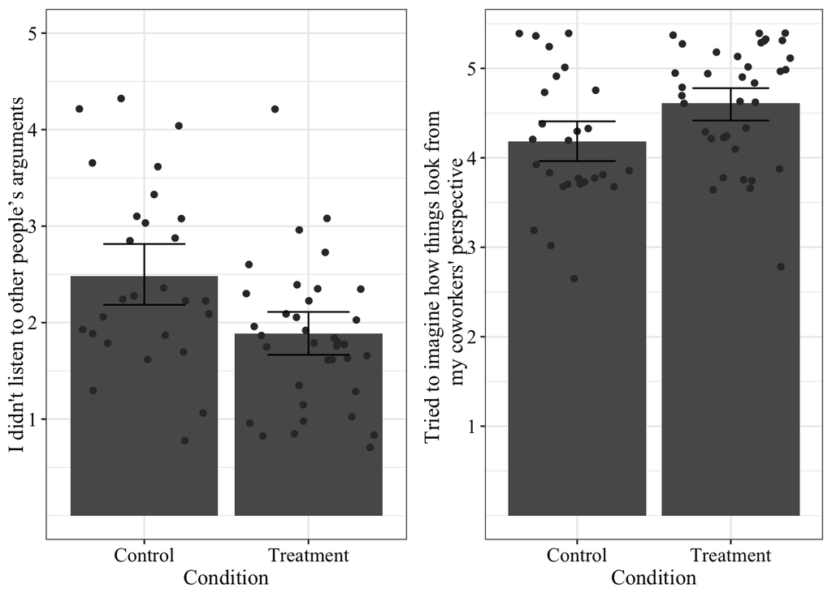

```r
ggarrange(plot1_S2, plot2_S2)
```

**c. 🔴**

**I believed that there are two sides to every question and tried to look at them both.**

```r
tab_model(lm(IRI_PT_3_S2 ~ Condition + wave, data))
```

|  | IRI_PT_3_S2 |  |  |
| --- | --- | --- | --- |
| Predictors | Estimates | CI | p |
| (Intercept) | 3.51 | 2.90 – 4.11 | **<0.001** |
| Condition [Treatment] | 0.32 | -0.08 – 0.72 | 0.114 |
| wave | 0.34 | -0.06 – 0.74 | 0.090 |
| Observations | 63 |  |  |
| R<sup>2</sup> / R<sup>2</sup> adjusted | 0.106 / 0.076 |  |  |

**d. 🔴**

*I tried to look at everybody’s side of a disagreement before I make a decision.*

```r
tab_model(lm(IRI_PT_4_S2 ~ Condition + wave, data))
```

|  | IRI_PT_4_S2 |  |  |
| --- | --- | --- | --- |
| Predictors | Estimates | CI | p |
| (Intercept) | 3.73 | 3.21 – 4.25 | **<0.001** |
| Condition [Treatment] | 0.21 | -0.14 – 0.55 | 0.238 |
| wave | 0.20 | -0.14 – 0.54 | 0.244 |
| Observations | 63 |  |  |
| R<sup>2</sup> / R<sup>2</sup> adjusted | 0.057 / 0.025 |  |  |

**Additional Outcomes**

## Trust 🔴

```r
data <- data %>%
  mutate(trustLeader_S2 = case_match(trustLeader_S2,
                                         1 ~ 5,
                                         2 ~ 4,
                                         3 ~ 3,
                                         4 ~ 2,
                                         5 ~ 1))

tab_model(lm(trustLeader_S2 ~ Condition, data))
```

|  | trustLeader_S2 |  |  |
| --- | --- | --- | --- |
| Predictors | Estimates | CI | p |
| (Intercept) | 3.77 | 3.33 – 4.21 | **<0.001** |
| Condition [Treatment] | -0.13 | -0.71 – 0.44 | 0.652 |
| Observations | 62 |  |  |
| R<sup>2</sup> / R<sup>2</sup> adjusted | 0.003 / -0.013 |  |  |

```r
kable(data %>%
  filter(!is.na(Condition), !is.na(trustLeader_S2)) %>%
  group_by(Condition) %>%
  summarise(mean(trustLeader_S2), sd(trustLeader_S2)))
```

| Condition | mean(trustLeader_S2) | sd(trustLeader_S2) |
| --- | --- | --- |
| Control | 3.769231 | 1.106623 |
| Treatment | 3.638889 | 1.125110 |

```r
data <- data %>%
  mutate(trustManager_S2 = case_match(trustManager_S2,
                                         1 ~ 5,
                                         2 ~ 4,
                                         3 ~ 3,
                                         4 ~ 2,
                                         5 ~ 1))

tab_model(lm(trustManager_S2 ~ Condition, data))
```

|  | trustManager_S2 |  |  |
| --- | --- | --- | --- |
| Predictors | Estimates | CI | p |
| (Intercept) | 3.96 | 3.48 – 4.44 | **<0.001** |
| Condition [Treatment] | -0.16 | -0.78 – 0.47 | 0.620 |
| Observations | 62 |  |  |
| R<sup>2</sup> / R<sup>2</sup> adjusted | 0.004 / -0.012 |  |  |

```r
kable(data %>%
  filter(!is.na(Condition), !is.na(trustManager_S2)) %>%
  group_by(Condition) %>%
  summarise(mean(trustManager_S2), sd(trustManager_S2)))
```

| Condition | mean(trustManager_S2) | sd(trustManager_S2) |
| --- | --- | --- |
| Control | 3.961539 | 0.958364 |
| Treatment | 3.805556 | 1.369451 |

## Burnout 🔴

```r
tab_model(lm(burnout_S2 ~ Condition, data))
```

|  | burnout_S2 |  |  |
| --- | --- | --- | --- |
| Predictors | Estimates | CI | p |
| (Intercept) | 4.00 | 3.34 – 4.66 | **<0.001** |
| Condition [Treatment] | 0.19 | -0.67 – 1.06 | 0.655 |
| Observations | 62 |  |  |
| R<sup>2</sup> / R<sup>2</sup> adjusted | 0.003 / -0.013 |  |  |

```r
kable(data %>%
  filter(!is.na(Condition), !is.na(burnout_S2)) %>%
  group_by(Condition) %>%
  summarise(mean(burnout_S2), sd(burnout_S2)))
```

| Condition | mean(burnout_S2) | sd(burnout_S2) |
| --- | --- | --- |
| Control | 4.000000 | 1.673320 |
| Treatment | 4.194444 | 1.687254 |

```r
tab_model(lm(burnout_S2 ~ Condition * manager + wave, data))
```

|  | burnout_S2 |  |  |
| --- | --- | --- | --- |
| Predictors | Estimates | CI | p |
| (Intercept) | 3.92 | 2.38 – 5.45 | **<0.001** |
| Condition [Treatment] | 0.65 | -0.46 – 1.77 | 0.246 |
| manager [Yes] | 0.77 | -0.60 – 2.15 | 0.265 |
| wave | -0.08 | -0.99 – 0.83 | 0.855 |
| Condition [Treatment] × manager [Yes] | -1.45 | -3.23 – 0.32 | 0.107 |
| Observations | 61 |  |  |
| R<sup>2</sup> / R<sup>2</sup> adjusted | 0.048 / -0.020 |  |  |

```r
tab_model(lm(burnout_S2 ~ Condition * URM + wave, data))
```

|  | burnout_S2 |  |  |
| --- | --- | --- | --- |
| Predictors | Estimates | CI | p |
| (Intercept) | 4.36 | 2.98 – 5.74 | **<0.001** |
| Condition [Treatment] | 0.34 | -0.64 – 1.32 | 0.488 |
| URM [Yes] | 0.03 | -1.67 – 1.73 | 0.970 |
| wave | -0.28 | -1.18 – 0.62 | 0.535 |
| Condition [Treatment] × URM [Yes] | -1.31 | -4.32 – 1.70 | 0.386 |
| Observations | 62 |  |  |
| R<sup>2</sup> / R<sup>2</sup> adjusted | 0.028 / -0.040 |  |  |

```r
tab_model(lm(burnout_S2 ~ Condition * gender + wave, data))
```

|  | burnout_S2 |  |  |
| --- | --- | --- | --- |
| Predictors | Estimates | CI | p |
| (Intercept) | 4.87 | 3.53 – 6.22 | **<0.001** |
| Condition [Treatment] | -0.63 | -1.69 – 0.42 | 0.234 |
| gender [Genderqueer or Nonbinary Gender] | -0.67 | -3.06 – 1.72 | 0.578 |
| gender [Male] | -2.40 | -3.92 – -0.88 | **0.002** |
| wave | -0.21 | -1.08 – 0.67 | 0.640 |
| Condition [Treatment] × gender [Genderqueer or Nonbinary Gender] | 1.04 | -1.97 – 4.04 | 0.491 |
| Condition [Treatment] × gender [Male] | 3.05 | 1.15 – 4.94 | **0.002** |
| Observations | 62 |  |  |
| R<sup>2</sup> / R<sup>2</sup> adjusted | 0.181 / 0.091 |  |  |

## Relationships

**a. 🔴**

*It is important to maintain a positive relationship with co-workers who are hard to work with.*

```r
data <- data %>%
  mutate(workerRelations1_S2 = case_match(workerRelations1_S2,
                                         1 ~ 5,
                                         2 ~ 4,
                                         3 ~ 3,
                                         4 ~ 2,
                                         5 ~ 1))

tab_model(lm(workerRelations1_S2 ~ Condition, data))
```

|  | workerRelations1_S2 |  |  |
| --- | --- | --- | --- |
| Predictors | Estimates | CI | p |
| (Intercept) | 3.92 | 3.55 – 4.29 | **<0.001** |
| Condition [Treatment] | 0.27 | -0.21 – 0.76 | 0.269 |
| Observations | 62 |  |  |
| R<sup>2</sup> / R<sup>2</sup> adjusted | 0.020 / 0.004 |  |  |

```r
kable(data %>%
  filter(!is.na(Condition), !is.na(workerRelations1_S2)) %>%
  group_by(Condition) %>%
  summarise(mean(workerRelations1_S2), sd(workerRelations1_S2)))
```

| Condition | mean(workerRelations1_S2) | sd(workerRelations1_S2) |
| --- | --- | --- |
| Control | 3.923077 | 0.7442084 |
| Treatment | 4.194444 | 1.0642085 |

```r
tab_model(lm(workerRelations1_S2 ~ Condition * manager + wave, data))
```

|  | workerRelations1_S2 |  |  |
| --- | --- | --- | --- |
| Predictors | Estimates | CI | p |
| (Intercept) | 4.27 | 3.38 – 5.15 | **<0.001** |
| Condition [Treatment] | 0.36 | -0.29 – 1.00 | 0.270 |
| manager [Yes] | 0.20 | -0.59 – 0.99 | 0.617 |
| wave | -0.34 | -0.86 – 0.19 | 0.206 |
| Condition [Treatment] × manager [Yes] | 0.05 | -0.98 – 1.07 | 0.924 |
| Observations | 61 |  |  |
| R<sup>2</sup> / R<sup>2</sup> adjusted | 0.071 / 0.005 |  |  |

**b. 🔴**

*There are certain co-workers that I come into conflict with and nothing can be done to change that.*

```r
data <- data %>%
  mutate(workerRelations2_S2 = case_match(workerRelations2_S2,
                                         1 ~ 5,
                                         2 ~ 4,
                                         3 ~ 3,
                                         4 ~ 2,
                                         5 ~ 1))

tab_model(lm(workerRelations2_S2 ~ Condition, data))
```

|  | workerRelations2_S2 |  |  |
| --- | --- | --- | --- |
| Predictors | Estimates | CI | p |
| (Intercept) | 3.08 | 2.61 – 3.54 | **<0.001** |
| Condition [Treatment] | -0.44 | -1.05 – 0.17 | 0.156 |
| Observations | 62 |  |  |
| R<sup>2</sup> / R<sup>2</sup> adjusted | 0.033 / 0.017 |  |  |

```r
kable(data %>%
  filter(!is.na(Condition), !is.na(workerRelations2_S2)) %>%
  group_by(Condition) %>%
  summarise(mean(workerRelations2_S2), sd(workerRelations2_S2)))
```

| Condition | mean(workerRelations2_S2) | sd(workerRelations2_S2) |
| --- | --- | --- |
| Control | 3.076923 | 1.293772 |
| Treatment | 2.638889 | 1.099423 |

```r
tab_model(lm(workerRelations2_S2 ~ Condition * manager + wave, data))
```

|  | workerRelations2_S2 |  |  |
| --- | --- | --- | --- |
| Predictors | Estimates | CI | p |
| (Intercept) | 3.15 | 2.06 – 4.24 | **<0.001** |
| Condition [Treatment] | -0.20 | -1.00 – 0.59 | 0.606 |
| manager [Yes] | 0.52 | -0.46 – 1.50 | 0.293 |
| wave | -0.16 | -0.80 – 0.49 | 0.630 |
| Condition [Treatment] × manager [Yes] | -0.70 | -1.96 – 0.56 | 0.272 |
| Observations | 61 |  |  |
| R<sup>2</sup> / R<sup>2</sup> adjusted | 0.077 / 0.011 |  |  |

**c. 🔴**

*A culture of harmonious working relationships is a top priority for me.*

```r
data <- data %>%
  mutate(workerRelations3_S2 = case_match(workerRelations3_S2,
                                         1 ~ 5,
                                         2 ~ 4,
                                         3 ~ 3,
                                         4 ~ 2,
                                         5 ~ 1))

tab_model(lm(workerRelations3_S2 ~ Condition, data))
```

|  | workerRelations3_S2 |  |  |
| --- | --- | --- | --- |
| Predictors | Estimates | CI | p |
| (Intercept) | 4.19 | 3.84 – 4.55 | **<0.001** |
| Condition [Treatment] | 0.31 | -0.16 – 0.77 | 0.191 |
| Observations | 62 |  |  |
| R<sup>2</sup> / R<sup>2</sup> adjusted | 0.028 / 0.012 |  |  |

```r
kable(data %>%
  filter(!is.na(Condition), !is.na(workerRelations3_S2)) %>%
  group_by(Condition) %>%
  summarise(mean(workerRelations3_S2), sd(workerRelations3_S2)))
```

| Condition | mean(workerRelations3_S2) | sd(workerRelations3_S2) |
| --- | --- | --- |
| Control | 4.192308 | 0.8952868 |
| Treatment | 4.500000 | 0.9102590 |

```r
tab_model(lm(workerRelations3_S2 ~ Condition * manager + wave, data))
```

|  | workerRelations3_S2 |  |  |
| --- | --- | --- | --- |
| Predictors | Estimates | CI | p |
| (Intercept) | 4.17 | 3.33 – 5.00 | **<0.001** |
| Condition [Treatment] | 0.29 | -0.31 – 0.90 | 0.338 |
| manager [Yes] | -0.40 | -1.15 – 0.36 | 0.295 |
| wave | 0.12 | -0.38 – 0.62 | 0.631 |
| Condition [Treatment] × manager [Yes] | -0.01 | -0.98 – 0.96 | 0.989 |
| Observations | 61 |  |  |
| R<sup>2</sup> / R<sup>2</sup> adjusted | 0.090 / 0.025 |  |  |

# Scenario

**Attributions 🔴**

```r
tab_model(lm(attributions_S2 ~ Condition, data))
```

|  | attributions_S2 |  |  |
| --- | --- | --- | --- |
| Predictors | Estimates | CI | p |
| (Intercept) | 2.56 | 2.18 – 2.94 | **<0.001** |
| Condition [Treatment] | -0.09 | -0.60 – 0.42 | 0.725 |
| Observations | 59 |  |  |
| R<sup>2</sup> / R<sup>2</sup> adjusted | 0.002 / -0.015 |  |  |

```r
kable(data %>%
  filter(!is.na(Condition), !is.na(attributions_S2)) %>%
  group_by(Condition) %>%
  summarise(mean(attributions_S2), sd(attributions_S2)))
```

| Condition | mean(attributions_S2) | sd(attributions_S2) |
| --- | --- | --- |
| Control | 2.560000 | 0.6506407 |
| Treatment | 2.470588 | 1.1344547 |

**Perspective-Taking 🟡**

```r
tab_model(lm(IRI_PT1_S2 ~ Condition, data))
```

|  | IRI_PT1_S2 |  |  |
| --- | --- | --- | --- |
| Predictors | Estimates | CI | p |
| (Intercept) | 3.72 | 3.34 – 4.10 | **<0.001** |
| Condition [Treatment] | 0.10 | -0.39 – 0.60 | 0.676 |
| Observations | 59 |  |  |
| R<sup>2</sup> / R<sup>2</sup> adjusted | 0.003 / -0.014 |  |  |

```r
kable(data %>%
  filter(!is.na(Condition), !is.na(IRI_PT1_S2)) %>%
  group_by(Condition) %>%
  summarise(mean(IRI_PT1_S2), sd(IRI_PT1_S2)))
```

| Condition | mean(IRI_PT1_S2) | sd(IRI_PT1_S2) |
| --- | --- | --- |
| Control | 3.720000 | 0.7916228 |
| Treatment | 3.823529 | 1.0289915 |

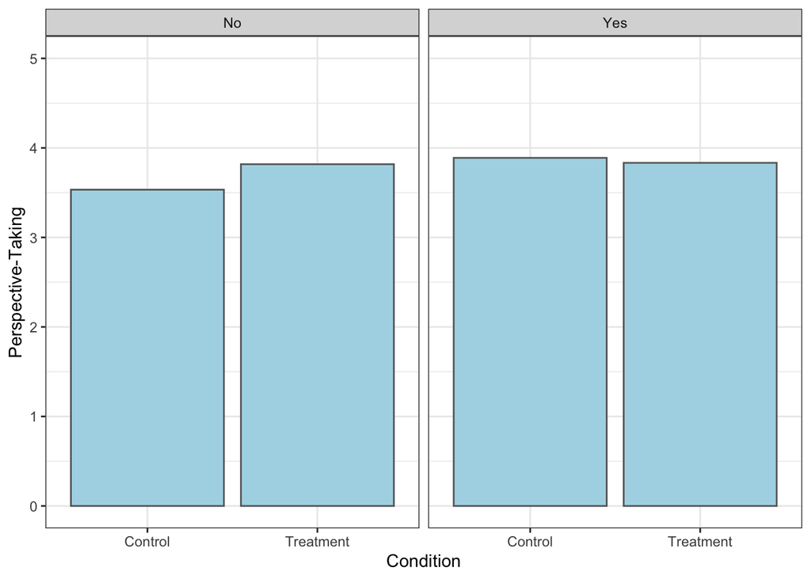

```r
data %>%
  filter(!is.na(Condition)) %>%
  filter(!is.na(manager)) %>%
ggplot(aes(x=Condition, y=IRI_PT1_S2)) +
  geom_bar(stat="summary", position="dodge", fill="lightblue", color = "grey40") +
  facet_wrap(~ manager) +
  expand_limits(y = c(1, 5)) +
  theme_bw() +
  labs(y = "Perspective-Taking")
```

```r
tab_model(lm(IRI_PT2_S2 ~ Condition, data))
```

|  | IRI_PT2_S2 |  |  |
| --- | --- | --- | --- |
| Predictors | Estimates | CI | p |
| (Intercept) | 3.72 | 3.38 – 4.06 | **<0.001** |
| Condition [Treatment] | 0.25 | -0.20 – 0.70 | 0.273 |
| Observations | 59 |  |  |
| R<sup>2</sup> / R<sup>2</sup> adjusted | 0.021 / 0.004 |  |  |

```r
kable(data %>%
  filter(!is.na(Condition), !is.na(IRI_PT2_S2)) %>%
  group_by(Condition) %>%
  summarise(mean(IRI_PT2_S2), sd(IRI_PT2_S2)))
```

| Condition | mean(IRI_PT2_S2) | sd(IRI_PT2_S2) |
| --- | --- | --- |
| Control | 3.720000 | 0.8426150 |
| Treatment | 3.970588 | 0.8698761 |

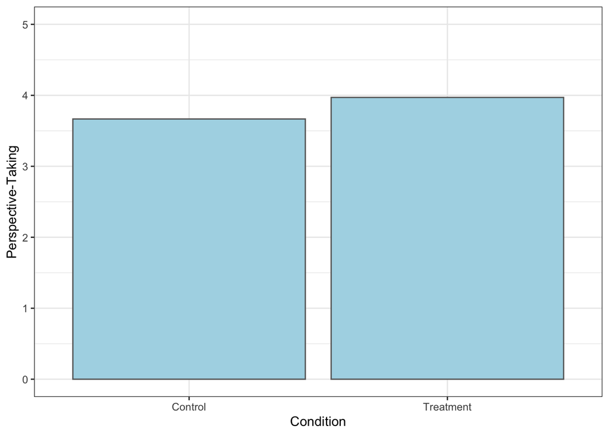

```r
data %>%
  filter(!is.na(Condition)) %>%
  filter(!is.na(manager)) %>%
ggplot(aes(x=Condition, y=IRI_PT2_S2)) +
  geom_bar(stat="summary", position="dodge", fill="lightblue", color = "grey40") +
  expand_limits(y = c(1, 5)) +
  theme_bw() +
  labs(y = "Perspective-Taking")
```

**360 🟡**

```r
tab_model(lm(X360_S2 ~ Condition, data))
```

|  | X360_S2 |  |  |
| --- | --- | --- | --- |
| Predictors | Estimates | CI | p |
| (Intercept) | 3.76 | 3.39 – 4.13 | **<0.001** |
| Condition [Treatment] | 0.42 | -0.08 – 0.91 | 0.095 |
| Observations | 59 |  |  |
| R<sup>2</sup> / R<sup>2</sup> adjusted | 0.048 / 0.031 |  |  |

```r
kable(data %>%
  filter(!is.na(Condition), !is.na(X360_S2)) %>%
  group_by(Condition) %>%
  summarise(mean(X360_S2), sd(X360_S2)))
```

| Condition | mean(X360_S2) | sd(X360_S2) |
| --- | --- | --- |
| Control | 3.760000 | 1.0519823 |
| Treatment | 4.176471 | 0.8337788 |

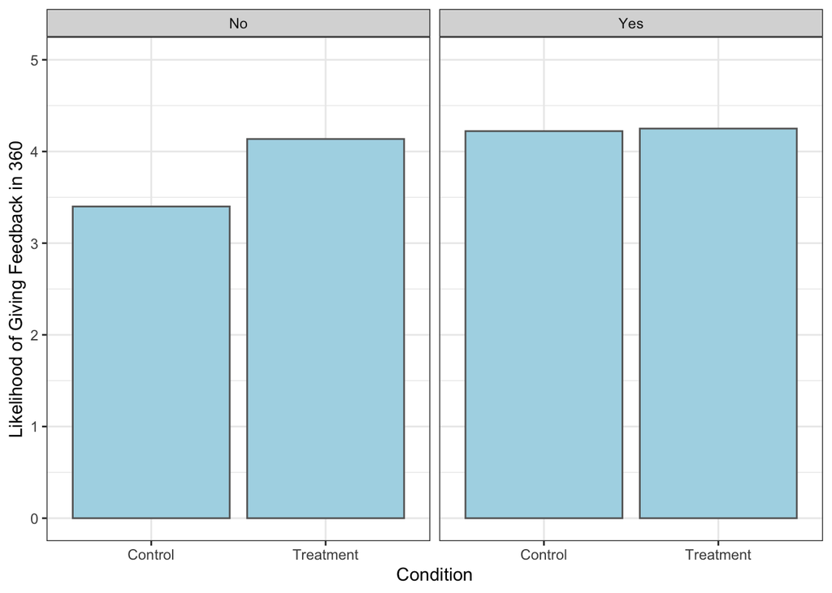

```r
data %>%
  filter(!is.na(Condition)) %>%
  filter(!is.na(manager)) %>%
ggplot(aes(x=Condition, y=X360_S2)) +
  geom_bar(stat="summary", position="dodge", fill="lightblue", color = "grey40") +
  facet_wrap(~ manager) +
  expand_limits(y = c(1, 5)) +
  theme_bw() +
  labs(y = "Likelihood of Giving Feedback in 360")
```

```r
tab_model(lm(X360Valence_S2 ~ Condition, data))
```

|  | X360Valence_S2 |  |  |
| --- | --- | --- | --- |
| Predictors | Estimates | CI | p |
| (Intercept) | 4.80 | 4.40 – 5.20 | **<0.001** |
| Condition [Treatment] | 0.17 | -0.36 – 0.70 | 0.520 |
| Observations | 59 |  |  |
| R<sup>2</sup> / R<sup>2</sup> adjusted | 0.007 / -0.010 |  |  |

```r
kable(data %>%
  filter(!is.na(Condition), !is.na(X360Valence_S2)) %>%
  group_by(Condition) %>%
  summarise(mean(X360Valence_S2), sd(X360Valence_S2)))
```

| Condition | mean(X360Valence_S2) | sd(X360Valence_S2) |
| --- | --- | --- |
| Control | 4.800000 | 0.7637626 |
| Treatment | 4.970588 | 1.1411131 |

**Complaint 🔴**

```r
data <- data %>%
  mutate(complaint_S2 = case_match(complaint_S2,
                                         1 ~ 5,
                                         2 ~ 4,
                                         3 ~ 3,
                                         4 ~ 2,
                                         5 ~ 1))

tab_model(lm(complaint_S2 ~ Condition, data))
```

|  | complaint_S2 |  |  |
| --- | --- | --- | --- |
| Predictors | Estimates | CI | p |
| (Intercept) | 2.04 | 1.59 – 2.49 | **<0.001** |
| Condition [Treatment] | 0.22 | -0.37 – 0.82 | 0.450 |
| Observations | 59 |  |  |
| R<sup>2</sup> / R<sup>2</sup> adjusted | 0.010 / -0.007 |  |  |

```r
kable(data %>%
  filter(!is.na(Condition), !is.na(complaint_S2)) %>%
  group_by(Condition) %>%
  summarise(mean(complaint_S2), sd(complaint_S2)))
```

| Condition | mean(complaint_S2) | sd(complaint_S2) |
| --- | --- | --- |
| Control | 2.040000 | 1.135782 |
| Treatment | 2.264706 | 1.109431 |

**Trust 🔴**

```r
data <- data %>%
  mutate(trustManagerScenario_S2 = case_match(trustManagerScenario_S2,
                                         1 ~ 5,
                                         2 ~ 4,
                                         3 ~ 3,
                                         4 ~ 2,
                                         5 ~ 1))

tab_model(lm(trustManagerScenario_S2 ~ Condition, data))
```

|  | trustManagerScenario_S2 |  |  |
| --- | --- | --- | --- |
| Predictors | Estimates | CI | p |
| (Intercept) | 1.76 | 1.48 – 2.04 | **<0.001** |
| Condition [Treatment] | -0.08 | -0.45 – 0.29 | 0.653 |
| Observations | 59 |  |  |
| R<sup>2</sup> / R<sup>2</sup> adjusted | 0.004 / -0.014 |  |  |

```r
kable(data %>%
  filter(!is.na(Condition), !is.na(trustManagerScenario_S2)) %>%
  group_by(Condition) %>%
  summarise(mean(trustManagerScenario_S2),
            sd(trustManagerScenario_S2)))
```

| Condition | mean(trustManagerScenario_S2) | sd(trustManagerScenario_S2) |
| --- | --- | --- |
| Control | 1.760000 | 0.8306624 |
| Treatment | 1.676471 | 0.5888143 |

**Evaluative Concerns 🔴**

```r
data <- data %>%
  mutate(evalConcern1_S2 = case_match(evalConcern1_S2,
                                         1 ~ 7,
                                         2 ~ 6,
                                         3 ~ 5,
                                         4 ~ 4,
                                         5 ~ 3,
                                         6 ~ 2,
                                         7 ~ 1)) %>%
  mutate(evalConcern2_S2 = case_match(evalConcern2_S2,
                                         1 ~ 7,
                                         2 ~ 6,
                                         3 ~ 5,
                                         4 ~ 4,
                                         5 ~ 3,
                                         6 ~ 2,
                                         7 ~ 1)) %>%
  mutate(evalConcern3_S2 = case_match(evalConcern3_S2,
                                         1 ~ 7,
                                         2 ~ 6,
                                         3 ~ 5,
                                         4 ~ 4,
                                         5 ~ 3,
                                         6 ~ 2,
                                         7 ~ 1)) %>%
   mutate(evalConcern4_S2 = case_match(evalConcern4_S2,
                                         1 ~ 7,
                                         2 ~ 6,
                                         3 ~ 5,
                                         4 ~ 4,
                                         5 ~ 3,
                                         6 ~ 2,
                                         7 ~ 1)) %>%
  mutate(evalConcern5_S2 = case_match(evalConcern5_S2,
                                         1 ~ 7,
                                         2 ~ 6,
                                         3 ~ 5,
                                         4 ~ 4,
                                         5 ~ 3,
                                         6 ~ 2,
                                         7 ~ 1))
evalConcern <- data %>%
  dplyr::select(evalConcern1_S2, evalConcern2_S2, evalConcern3_S2, evalConcern4_S2, evalConcern5_S2)

keys <- list("evalConcern1_S2", "evalConcern2_S2", "evalConcern3_S2", "evalConcern4_S2", "evalConcern5_S2")

kable(alpha(evalConcern, na.rm=T, check.keys=T)$alpha)
```

|  | raw_alpha | std.alpha | G6(smc) | average_r | S/N | alpha se | var.r | med.r |
| --- | --- | --- | --- | --- | --- | --- | --- | --- |
| evalConcern1_S2 | 0.8771823 | 0.8786086 | 0.8702081 | 0.6440589 | 7.237816 | 0.0133156 | 0.0144860 | 0.6911422 |
| evalConcern2_S2 | 0.8533006 | 0.8545133 | 0.8402902 | 0.5948743 | 5.873479 | 0.0159208 | 0.0146866 | 0.6280084 |
| evalConcern3_S2 | 0.9044232 | 0.9078926 | 0.8972493 | 0.7113351 | 9.856897 | 0.0109335 | 0.0076323 | 0.6960958 |
| evalConcern4_S2 | 0.8799269 | 0.8777209 | 0.8922900 | 0.6421547 | 7.178015 | 0.0135036 | 0.0298965 | 0.6807985 |
| evalConcern5_S2 | 0.8485128 | 0.8485087 | 0.8430583 | 0.5833784 | 5.601039 | 0.0165205 | 0.0251377 | 0.5532415 |

```r
evalConcern_S2 <- scoreItems(keys, evalConcern, min = 1, max = 7)
```

$\alpha = 0.88$

```r
tab_model(lm(evalConcern1_S2 ~ Condition, data))
```

|  | evalConcern1_S2 |  |  |
| --- | --- | --- | --- |
| Predictors | Estimates | CI | p |
| (Intercept) | 5.04 | 4.31 – 5.77 | **<0.001** |
| Condition [Treatment] | -0.30 | -1.27 – 0.66 | 0.531 |
| Observations | 59 |  |  |
| R<sup>2</sup> / R<sup>2</sup> adjusted | 0.007 / -0.010 |  |  |

```r
kable(data %>%
  filter(!is.na(Condition), !is.na(evalConcern1_S2)) %>%
  group_by(Condition) %>%
  summarise(mean(evalConcern1_S2), sd(evalConcern1_S2)))
```

| Condition | mean(evalConcern1_S2) | sd(evalConcern1_S2) |
| --- | --- | --- |
| Control | 5.040000 | 1.485485 |
| Treatment | 4.735294 | 2.049521 |

```r
tab_model(lm(evalConcern2_S2 ~ Condition, data))
```

|  | evalConcern2_S2 |  |  |
| --- | --- | --- | --- |
| Predictors | Estimates | CI | p |
| (Intercept) | 5.40 | 4.70 – 6.10 | **<0.001** |
| Condition [Treatment] | -0.14 | -1.06 – 0.79 | 0.770 |
| Observations | 59 |  |  |
| R<sup>2</sup> / R<sup>2</sup> adjusted | 0.002 / -0.016 |  |  |

```r
kable(data %>%
  filter(!is.na(Condition), !is.na(evalConcern2_S2)) %>%
  group_by(Condition) %>%
  summarise(mean(evalConcern2_S2), sd(evalConcern2_S2)))
```

| Condition | mean(evalConcern2_S2) | sd(evalConcern2_S2) |
| --- | --- | --- |
| Control | 5.400000 | 1.443376 |
| Treatment | 5.264706 | 1.943269 |

```r
tab_model(lm(evalConcern3_S2 ~ Condition, data))
```

|  | evalConcern3_S2 |  |  |
| --- | --- | --- | --- |
| Predictors | Estimates | CI | p |
| (Intercept) | 5.52 | 4.89 – 6.15 | **<0.001** |
| Condition [Treatment] | 0.51 | -0.32 – 1.33 | 0.221 |
| Observations | 59 |  |  |
| R<sup>2</sup> / R<sup>2</sup> adjusted | 0.026 / 0.009 |  |  |

```r
kable(data %>%
  filter(!is.na(Condition), !is.na(evalConcern3_S2)) %>%
  group_by(Condition) %>%
  summarise(mean(evalConcern3_S2), sd(evalConcern3_S2)))
```

| Condition | mean(evalConcern3_S2) | sd(evalConcern3_S2) |
| --- | --- | --- |
| Control | 5.520000 | 1.610383 |
| Treatment | 6.029412 | 1.527233 |

```r
tab_model(lm(evalConcern4_S2 ~ Condition, data))
```

|  | evalConcern4_S2 |  |  |
| --- | --- | --- | --- |
| Predictors | Estimates | CI | p |
| (Intercept) | 5.20 | 4.38 – 6.02 | **<0.001** |
| Condition [Treatment] | -0.46 | -1.54 – 0.61 | 0.392 |
| Observations | 59 |  |  |
| R<sup>2</sup> / R<sup>2</sup> adjusted | 0.013 / -0.004 |  |  |

```r
kable(data %>%
  filter(!is.na(Condition), !is.na(evalConcern4_S2)) %>%
  group_by(Condition) %>%
  summarise(mean(evalConcern4_S2), sd(evalConcern4_S2)))
```

| Condition | mean(evalConcern4_S2) | sd(evalConcern4_S2) |
| --- | --- | --- |
| Control | 5.200000 | 1.707825 |
| Treatment | 4.735294 | 2.260448 |

```r
tab_model(lm(evalConcern5_S2 ~ Condition, data))
```

|  | evalConcern5_S2 |  |  |
| --- | --- | --- | --- |
| Predictors | Estimates | CI | p |
| (Intercept) | 5.52 | 4.76 – 6.28 | **<0.001** |
| Condition [Treatment] | 0.01 | -0.99 – 1.00 | 0.985 |
| Observations | 59 |  |  |
| R<sup>2</sup> / R<sup>2</sup> adjusted | 0.000 / -0.018 |  |  |

```r
kable(data %>%
  filter(!is.na(Condition), !is.na(evalConcern5_S2)) %>%
  group_by(Condition) %>%
  summarise(mean(evalConcern5_S2), sd(evalConcern5_S2)))
```

| Condition | mean(evalConcern5_S2) | sd(evalConcern5_S2) |
| --- | --- | --- |
| Control | 5.520000 | 1.758787 |
| Treatment | 5.529412 | 1.973081 |

```r
data$evalConcernsAvg_S2 <- ((data$evalConcern1_S2 + data$evalConcern2_S2 + data$evalConcern3_S2 + data$evalConcern4_S2 + data$evalConcern5_S2)/5)

tab_model(lm(evalConcernsAvg_S2 ~ Condition, data))
```

|  | evalConcernsAvg_S2 |  |  |
| --- | --- | --- | --- |
| Predictors | Estimates | CI | p |
| (Intercept) | 5.34 | 4.72 – 5.95 | **<0.001** |
| Condition [Treatment] | -0.08 | -0.89 – 0.73 | 0.849 |
| Observations | 59 |  |  |
| R<sup>2</sup> / R<sup>2</sup> adjusted | 0.001 / -0.017 |  |  |

```r
kable(data %>%
  filter(!is.na(Condition), !is.na(evalConcernsAvg_S2)) %>%
  group_by(Condition) %>%
  summarise(mean(evalConcernsAvg_S2), sd(evalConcernsAvg_S2)))
```

| Condition | mean(evalConcernsAvg_S2) | sd(evalConcernsAvg_S2) |
| --- | --- | --- |
| Control | 5.336000 | 1.349963 |
| Treatment | 5.258824 | 1.651834 |

**Engagement 🔴**

```r
data <- data %>%
  mutate(engagement1_S2 = case_match(engagement1_S2,
                                         1 ~ 7,
                                         2 ~ 6,
                                         3 ~ 5,
                                         4 ~ 4,
                                         5 ~ 3,
                                         6 ~ 2,
                                         7 ~ 1)) %>%
  mutate(engagement2_S2 = case_match(engagement2_S2,
                                         1 ~ 7,
                                         2 ~ 6,
                                         3 ~ 5,
                                         4 ~ 4,
                                         5 ~ 3,
                                         6 ~ 2,
                                         7 ~ 1)) %>%
  mutate(engagment3_S2 = case_match(engagment3_S2,
                                         1 ~ 7,
                                         2 ~ 6,
                                         3 ~ 5,
                                         4 ~ 4,
                                         5 ~ 3,
                                         6 ~ 2,
                                         7 ~ 1))

engagement <- data %>%
  dplyr::select(engagement1_S2, engagement2_S2, engagment3_S2)

keys <- list("engagement1_S2", "engagement2_S2", "engagment3_S2")

kable(alpha(engagement, na.rm=T, check.keys=T)$alpha)
```

|  | raw_alpha | std.alpha | G6(smc) | average_r | S/N | alpha se | var.r | med.r |
| --- | --- | --- | --- | --- | --- | --- | --- | --- |
| engagement1_S2 | 0.7044334 | 0.7180464 | 0.5601189 | 0.5601189 | 2.546683 | 0.0386291 | NA | 0.5601189 |
| engagement2_S2 | 0.6345637 | 0.6435150 | 0.4743989 | 0.4743989 | 1.805167 | 0.0485460 | NA | 0.4743989 |
| engagment3_S2 | 0.9341700 | 0.9345954 | 0.8772211 | 0.8772211 | 14.289439 | 0.0089460 | NA | 0.8772211 |

```r
engagement_S2 <- scoreItems(keys, engagement, min = 1, max = 7)
```

$\alpha = 0.85$

```r
data$engagementAvg_S2 <- ((data$engagement1_S2 + data$engagement2_S2 + data$engagment3_S2)/3)

tab_model(lm(engagementAvg_S2 ~ Condition, data))
```

|  | engagementAvg_S2 |  |  |
| --- | --- | --- | --- |
| Predictors | Estimates | CI | p |
| (Intercept) | 3.37 | 2.75 – 4.00 | **<0.001** |
| Condition [Treatment] | -0.07 | -0.89 – 0.75 | 0.866 |
| Observations | 59 |  |  |
| R<sup>2</sup> / R<sup>2</sup> adjusted | 0.001 / -0.017 |  |  |

```r
kable(data %>%
  filter(!is.na(Condition), !is.na(engagementAvg_S2)) %>%
  group_by(Condition) %>%
  summarise(mean(engagementAvg_S2), sd(engagementAvg_S2)))
```

| Condition | mean(engagementAvg_S2) | sd(engagementAvg_S2) |
| --- | --- | --- |
| Control | 3.373333 | 1.444402 |
| Treatment | 3.303922 | 1.631689 |

```r
tab_model(lm(engagement1_S2 ~ Condition, data))
```

|  | engagement1_S2 |  |  |
| --- | --- | --- | --- |
| Predictors | Estimates | CI | p |
| (Intercept) | 4.36 | 3.63 – 5.09 | **<0.001** |
| Condition [Treatment] | -0.12 | -1.09 – 0.84 | 0.797 |
| Observations | 59 |  |  |
| R<sup>2</sup> / R<sup>2</sup> adjusted | 0.001 / -0.016 |  |  |

```r
kable(data %>%
  filter(!is.na(Condition), !is.na(engagement1_S2)) %>%
  group_by(Condition) %>%
  summarise(mean(engagement1_S2), sd(engagement1_S2)))
```

| Condition | mean(engagement1_S2) | sd(engagement1_S2) |
| --- | --- | --- |
| Control | 4.360000 | 1.655294 |
| Treatment | 4.235294 | 1.954929 |

```r
tab_model(lm(engagement2_S2 ~ Condition, data))
```

|  | engagement2_S2 |  |  |
| --- | --- | --- | --- |
| Predictors | Estimates | CI | p |
| (Intercept) | 3.52 | 2.77 – 4.27 | **<0.001** |
| Condition [Treatment] | -0.14 | -1.12 – 0.85 | 0.780 |
| Observations | 59 |  |  |
| R<sup>2</sup> / R<sup>2</sup> adjusted | 0.001 / -0.016 |  |  |

```r
kable(data %>%
  filter(!is.na(Condition), !is.na(engagement2_S2)) %>%
  group_by(Condition) %>%
  summarise(mean(engagement2_S2), sd(engagement2_S2)))
```

| Condition | mean(engagement2_S2) | sd(engagement2_S2) |
| --- | --- | --- |
| Control | 3.520000 | 1.734935 |
| Treatment | 3.382353 | 1.954245 |

```r
tab_model(lm(engagment3_S2 ~ Condition, data))
```

|  | engagment3_S2 |  |  |
| --- | --- | --- | --- |
| Predictors | Estimates | CI | p |
| (Intercept) | 2.24 | 1.65 – 2.83 | **<0.001** |
| Condition [Treatment] | 0.05 | -0.73 – 0.84 | 0.890 |
| Observations | 59 |  |  |
| R<sup>2</sup> / R<sup>2</sup> adjusted | 0.000 / -0.017 |  |  |

```r
kable(data %>%
  filter(!is.na(Condition), !is.na(engagment3_S2)) %>%
  group_by(Condition) %>%
  summarise(mean(engagment3_S2), sd(engagment3_S2)))
```

| Condition | mean(engagment3_S2) | sd(engagment3_S2) |
| --- | --- | --- |
| Control | 2.240000 | 1.422439 |
| Treatment | 2.294118 | 1.528109 |

**Manager**

**Environment 🔴**

```r
data <- data %>%
  mutate(managerEnvironment_S2 = case_match(managerEnvironment_S2,
                                         1 ~ 6,
                                         2 ~ 5,
                                         3 ~ 4,
                                         4 ~ 3,
                                         5 ~ 2,
                                         6 ~ 1))

tab_model(lm(managerEnvironment_S2 ~ Condition, data))
```

|  | managerEnvironment_S2 |  |  |
| --- | --- | --- | --- |
| Predictors | Estimates | CI | p |
| (Intercept) | 2.28 | 1.82 – 2.74 | **<0.001** |
| Condition [Treatment] | -0.31 | -0.92 – 0.30 | 0.313 |
| Observations | 59 |  |  |
| R<sup>2</sup> / R<sup>2</sup> adjusted | 0.018 / 0.001 |  |  |

```r
kable(data %>%
  filter(!is.na(Condition), !is.na(managerEnvironment_S2)) %>%
  group_by(Condition) %>%
  summarise(mean(managerEnvironment_S2), sd(managerEnvironment_S2)))
```

| Condition | mean(managerEnvironment_S2) | sd(managerEnvironment_S2) |
| --- | --- | --- |
| Control | 2.280000 | 1.307670 |
| Treatment | 1.970588 | 1.029424 |

**Mindset 🔴**

```r
data <- data %>%
  mutate(managerMindset1_S2 = case_match(managerMindset1_S2,
                                         1 ~ 6,
                                         2 ~ 5,
                                         3 ~ 4,
                                         4 ~ 3,
                                         5 ~ 2,
                                         6 ~ 1)) %>%
  mutate(managerMindset2_S2 = case_match(managerMindset2_S2,
                                         1 ~ 6,
                                         2 ~ 5,
                                         3 ~ 4,
                                         4 ~ 3,
                                         5 ~ 2,
                                         6 ~ 1)) %>%
  mutate(managerMindset3_S2 = case_match(managerMindset3_S2,
                                         1 ~ 6,
                                         2 ~ 5,
                                         3 ~ 4,
                                         4 ~ 3,
                                         5 ~ 2,
                                         6 ~ 1)) %>%
   mutate(managerMindset4_S2 = case_match(managerMindset4_S2,
                                         1 ~ 6,
                                         2 ~ 5,
                                         3 ~ 4,
                                         4 ~ 3,
                                         5 ~ 2,
                                         6 ~ 1)) %>%
  mutate(managerMindset5_S2 = case_match(managerMindset5_S2,
                                         1 ~ 6,
                                         2 ~ 5,
                                         3 ~ 4,
                                         4 ~ 3,
                                         5 ~ 2,
                                         6 ~ 1)) %>%
  mutate(managerMindset6_S2 = case_match(managerMindset6_S2,
                                         1 ~ 6,
                                         2 ~ 5,
                                         3 ~ 4,
                                         4 ~ 3,
                                         5 ~ 2,
                                         6 ~ 1))

mindset <- data %>%
  dplyr::select(managerMindset1_S2, managerMindset2_S2, managerMindset3_S2, managerMindset4_S2, managerMindset5_S2, managerMindset6_S2)

keys <- list("managerMindset1_S2", "managerMindset2_S2", "managerMindset3_S2", "managerMindset4_S2", "managerMindset5_S2", "managerMindset6_S2")

kable(alpha(mindset, na.rm=T, check.keys=T)$alpha)
```

|  | raw_alpha | std.alpha | G6(smc) | average_r | S/N | alpha se | var.r | med.r |
| --- | --- | --- | --- | --- | --- | --- | --- | --- |
| managerMindset1_S2 | 0.8944030 | 0.8817955 | 0.9104514 | 0.5987132 | 7.459916 | 0.0099194 | 0.0876682 | 0.7592096 |
| managerMindset2_S2 | 0.8853406 | 0.8717030 | 0.8913073 | 0.5760705 | 6.794414 | 0.0106466 | 0.0869582 | 0.7404556 |
| managerMindset3_S2 | 0.8843674 | 0.8718067 | 0.8974813 | 0.5762970 | 6.800718 | 0.0110861 | 0.0802809 | 0.7213526 |
| managerMindset4_S2 | 0.9509619 | 0.9525581 | 0.9569878 | 0.8006254 | 20.078416 | 0.0053619 | 0.0040468 | 0.7988163 |
| managerMindset5_S2 | 0.8884309 | 0.8753900 | 0.8884037 | 0.5842008 | 7.025035 | 0.0103259 | 0.0838842 | 0.7677437 |
| managerMindset6_S2 | 0.8823848 | 0.8684314 | 0.8827479 | 0.5689877 | 6.600596 | 0.0109033 | 0.0769676 | 0.7213526 |

```r
mindset_S2 <- scoreItems(keys, mindset, min = 1, max = 6)
```

```r
data$mindsetAvg_S2 <- ((data$managerMindset1_S2 + data$managerMindset2_S2 + data$managerMindset3_S2 + data$managerMindset4_S2 + data$managerMindset5_S2 + data$managerMindset6_S2)/6)

tab_model(lm(mindsetAvg_S2 ~ Condition, data))
```

|  | mindsetAvg_S2 |  |  |
| --- | --- | --- | --- |
| Predictors | Estimates | CI | p |
| (Intercept) | 3.21 | 2.83 – 3.60 | **<0.001** |
| Condition [Treatment] | 0.10 | -0.41 – 0.61 | 0.694 |
| Observations | 59 |  |  |
| R<sup>2</sup> / R<sup>2</sup> adjusted | 0.003 / -0.015 |  |  |

```r
kable(data %>%
  filter(!is.na(Condition), !is.na(mindsetAvg_S2)) %>%
  group_by(Condition) %>%
  summarise(mean(mindsetAvg_S2), sd(mindsetAvg_S2)))
```

| Condition | mean(mindsetAvg_S2) | sd(mindsetAvg_S2) |
| --- | --- | --- |
| Control | 3.213333 | 0.9913048 |
| Treatment | 3.313725 | 0.9408112 |

```r
tab_model(lm(managerMindset1_S2 ~ Condition, data))
```

|  | managerMindset1_S2 |  |  |
| --- | --- | --- | --- |
| Predictors | Estimates | CI | p |
| (Intercept) | 3.24 | 2.73 – 3.75 | **<0.001** |
| Condition [Treatment] | 0.20 | -0.47 – 0.87 | 0.548 |
| Observations | 59 |  |  |
| R<sup>2</sup> / R<sup>2</sup> adjusted | 0.006 / -0.011 |  |  |

```r
tab_model(lm(managerMindset2_S2 ~ Condition, data))
```

|  | managerMindset2_S2 |  |  |
| --- | --- | --- | --- |
| Predictors | Estimates | CI | p |
| (Intercept) | 3.12 | 2.67 – 3.57 | **<0.001** |
| Condition [Treatment] | 0.17 | -0.42 – 0.77 | 0.558 |
| Observations | 59 |  |  |
| R<sup>2</sup> / R<sup>2</sup> adjusted | 0.006 / -0.011 |  |  |

```r
tab_model(lm(managerMindset3_S2 ~ Condition, data))
```

|  | managerMindset3_S2 |  |  |
| --- | --- | --- | --- |
| Predictors | Estimates | CI | p |
| (Intercept) | 3.40 | 2.87 – 3.93 | **<0.001** |
| Condition [Treatment] | 0.28 | -0.43 – 0.98 | 0.435 |
| Observations | 59 |  |  |
| R<sup>2</sup> / R<sup>2</sup> adjusted | 0.011 / -0.007 |  |  |

```r
summary(lm(managerMindset4_S2 ~ Condition, data))
```

```
Call:
lm(formula = managerMindset4_S2 ~ Condition, data = data)

Residuals:
    Min      1Q  Median      3Q     Max
-1.8400 -0.7941  0.1600  0.2059  2.1600

Coefficients:
                   Estimate Std. Error t value Pr(>|t|)
(Intercept)         2.84000    0.16526  17.185   <2e-16 ***
ConditionTreatment -0.04588    0.21770  -0.211    0.834
---
Signif. codes:  0 '***' 0.001 '**' 0.01 '*' 0.05 '.' 0.1 ' ' 1

Residual standard error: 0.8263 on 57 degrees of freedom
  (156 observations deleted due to missingness)
Multiple R-squared:  0.0007787, Adjusted R-squared:  -0.01675
F-statistic: 0.04442 on 1 and 57 DF,  p-value: 0.8338
```

```r
summary(lm(managerMindset5_S2 ~ Condition, data))
```

```
Call:
lm(formula = managerMindset5_S2 ~ Condition, data = data)

Residuals:
   Min     1Q Median     3Q    Max
-2.382 -1.320 -0.320  0.680  2.618

Coefficients:
                   Estimate Std. Error t value Pr(>|t|)
(Intercept)         3.32000    0.23911  13.885   <2e-16 ***
ConditionTreatment  0.06235    0.31498   0.198    0.844
---
Signif. codes:  0 '***' 0.001 '**' 0.01 '*' 0.05 '.' 0.1 ' ' 1

Residual standard error: 1.196 on 57 degrees of freedom
  (156 observations deleted due to missingness)
Multiple R-squared:  0.000687,  Adjusted R-squared:  -0.01684
F-statistic: 0.03919 on 1 and 57 DF,  p-value: 0.8438
```

```r
summary(lm(managerMindset6_S2 ~ Condition, data))
```

```
Call:
lm(formula = managerMindset6_S2 ~ Condition, data = data)

Residuals:
    Min      1Q  Median      3Q     Max
-2.3600 -0.3600 -0.2941  0.7059  2.7059

Coefficients:
                   Estimate Std. Error t value Pr(>|t|)
(Intercept)         3.36000    0.21976  15.289   <2e-16 ***
ConditionTreatment -0.06588    0.28949  -0.228    0.821
---
Signif. codes:  0 '***' 0.001 '**' 0.01 '*' 0.05 '.' 0.1 ' ' 1

Residual standard error: 1.099 on 57 degrees of freedom
  (156 observations deleted due to missingness)
Multiple R-squared:  0.0009078, Adjusted R-squared:  -0.01662
F-statistic: 0.05179 on 1 and 57 DF,  p-value: 0.8208
```

# Belonging

```r
belonging <- data %>%
  dplyr::select(belonging1_S2, belonging2_S2, belonging3_S2, belonging4_S2, belonging5_S2)

keys <- list("belonging1_S2", "belonging2_S2", "belonging3_S2", "belonging4_S2", "belonging5_S2")

kable(alpha(belonging, na.rm=T, check.keys=T)$alpha)
```

|  | raw_alpha | std.alpha | G6(smc) | average_r | S/N | alpha se | var.r | med.r |
| --- | --- | --- | --- | --- | --- | --- | --- | --- |
| belonging1_S2 | 0.8824144 | 0.8899128 | 0.8681049 | 0.6689758 | 8.083709 | 0.0130487 | 0.0069842 | 0.6757376 |
| belonging2_S2 | 0.8818670 | 0.8914188 | 0.8699036 | 0.6723915 | 8.209696 | 0.0133132 | 0.0076630 | 0.6757376 |
| belonging3_S2 | 0.8739208 | 0.8810092 | 0.8561607 | 0.6492463 | 7.404014 | 0.0139347 | 0.0042117 | 0.6606003 |
| belonging4_S2- | 0.9082592 | 0.9090350 | 0.8910660 | 0.7141476 | 9.993236 | 0.0103950 | 0.0056720 | 0.6957390 |
| belonging5_S2 | 0.9030299 | 0.9116847 | 0.8956576 | 0.7207301 | 10.323061 | 0.0108379 | 0.0048667 | 0.7080847 |

```r
belonging_S2 <- scoreItems(keys, belonging, min = 1, max = 6)
```

$\alpha = 0.91$

```r
data$belongingAvg_S2 <- ((data$belonging1_S2 + data$belonging2_S2 + data$belonging3_S2 + data$belonging4_S2 + data$belonging5_S2)/5)

tab_model(lm(belongingAvg_S2 ~ Condition, data))
```

|  | belongingAvg_S2 |  |  |
| --- | --- | --- | --- |
| Predictors | Estimates | CI | p |
| (Intercept) | 3.05 | 2.80 – 3.30 | **<0.001** |
| Condition [Treatment] | 0.22 | -0.10 – 0.55 | 0.177 |
| Observations | 62 |  |  |
| R<sup>2</sup> / R<sup>2</sup> adjusted | 0.030 / 0.014 |  |  |

```r
kable(data %>%
  filter(!is.na(Condition), !is.na(belongingAvg_S2)) %>%
  group_by(Condition) %>%
  summarise(mean(belongingAvg_S2), sd(belongingAvg_S2)))
```

| Condition | mean(belongingAvg_S2) | sd(belongingAvg_S2) |
| --- | --- | --- |
| Control | 3.053846 | 0.4545158 |
| Treatment | 3.277778 | 0.7395408 |

```r
tab_model(lm(belongingAvg_S2 ~ Condition * manager + wave, data))
```

|  | belongingAvg_S2 |  |  |
| --- | --- | --- | --- |
| Predictors | Estimates | CI | p |
| (Intercept) | 2.80 | 2.22 – 3.37 | **<0.001** |
| Condition [Treatment] | 0.35 | -0.06 – 0.77 | 0.095 |
| manager [Yes] | 0.07 | -0.45 – 0.59 | 0.784 |
| wave | 0.19 | -0.15 – 0.53 | 0.263 |
| Condition [Treatment] × manager [Yes] | -0.55 | -1.22 – 0.12 | 0.104 |
| Observations | 61 |  |  |
| R<sup>2</sup> / R<sup>2</sup> adjusted | 0.132 / 0.070 |  |  |

```r
tab_model(lm(belongingAvg_S2 ~ Condition * URM + wave, data))
```

|  | belongingAvg_S2 |  |  |
| --- | --- | --- | --- |
| Predictors | Estimates | CI | p |
| (Intercept) | 2.78 | 2.27 – 3.30 | **<0.001** |
| Condition [Treatment] | 0.15 | -0.21 – 0.51 | 0.416 |
| URM [Yes] | 0.06 | -0.57 – 0.69 | 0.852 |
| wave | 0.20 | -0.14 – 0.53 | 0.241 |
| Condition [Treatment] × URM [Yes] | 0.61 | -0.51 – 1.73 | 0.279 |
| Observations | 62 |  |  |
| R<sup>2</sup> / R<sup>2</sup> adjusted | 0.087 / 0.022 |  |  |

```r
tab_model(lm(belongingAvg_S2 ~ Condition * gender, data))
```

|  | belongingAvg_S2 |  |  |
| --- | --- | --- | --- |
| Predictors | Estimates | CI | p |
| (Intercept) | 3.00 | 2.71 – 3.29 | **<0.001** |
| Condition [Treatment] | 0.12 | -0.29 – 0.52 | 0.567 |
| gender [Genderqueer or Nonbinary Gender] | -0.30 | -1.21 – 0.61 | 0.513 |
| gender [Male] | 0.33 | -0.24 – 0.91 | 0.253 |
| Condition [Treatment] × gender [Genderqueer or Nonbinary Gender] | 1.18 | 0.05 – 2.32 | **0.041** |
| Condition [Treatment] × gender [Male] | -0.16 | -0.88 – 0.57 | 0.667 |
| Observations | 62 |  |  |
| R<sup>2</sup> / R<sup>2</sup> adjusted | 0.164 / 0.090 |  |  |

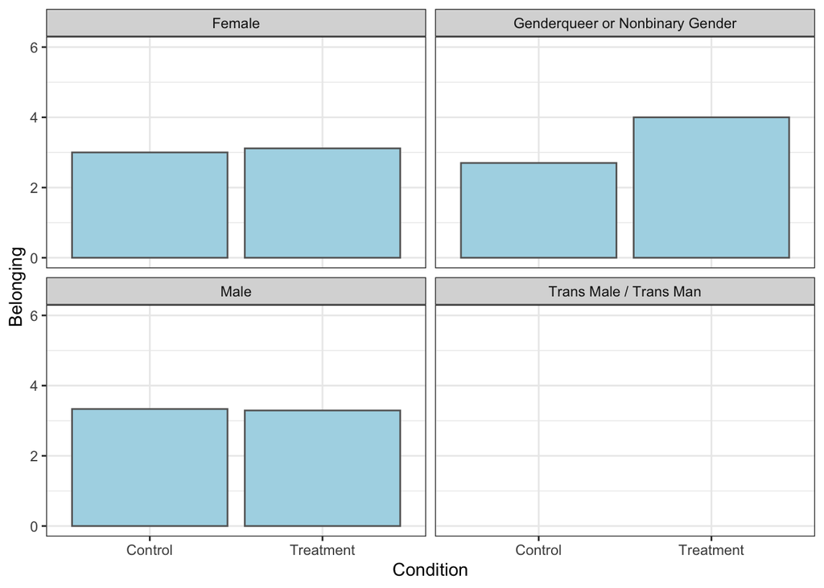

```r
data %>%
  filter(!is.na(Condition)) %>%
  filter(!is.na(gender)) %>%
ggplot(aes(x=Condition, y=belongingAvg_S2)) +
  geom_bar(stat="summary", position="dodge", fill="lightblue", color = "grey40") +
  facet_wrap(~ gender) +
  expand_limits(y = c(1, 6)) +
  theme_bw() +
  labs(y = "Belonging")
```

# Sense of Fit

```r
fit <- data %>%
  dplyr::select(fit1_S2, fit2_S2, fit3_S2)

kable(alpha(fit, na.rm=T, check.keys=T)$alpha)
```

|  | raw_alpha | std.alpha | G6(smc) | average_r | S/N | alpha se | var.r | med.r |
| --- | --- | --- | --- | --- | --- | --- | --- | --- |
| fit1_S2 | 0.9488421 | 0.9490153 | 0.9029773 | 0.9029773 | 18.613722 | 0.0069648 | NA | 0.9029773 |
| fit2_S2 | 0.8056094 | 0.8104895 | 0.6813638 | 0.6813638 | 4.276752 | 0.0260221 | NA | 0.6813638 |
| fit3_S2 | 0.8450585 | 0.8483499 | 0.7366385 | 0.7366385 | 5.594125 | 0.0208271 | NA | 0.7366385 |

$\alpha = 0.91$

```r
data$fitAvg_S2 <- ((data$fit1_S2 + data$fit2_S2 + data$fit3_S2)/3)

tab_model(lm(fitAvg_S2 ~ Condition, data))
```

|  | fitAvg_S2 |  |  |
| --- | --- | --- | --- |
| Predictors | Estimates | CI | p |
| (Intercept) | 2.45 | 1.99 – 2.91 | **<0.001** |
| Condition [Treatment] | 0.08 | -0.52 – 0.68 | 0.793 |
| Observations | 62 |  |  |
| R<sup>2</sup> / R<sup>2</sup> adjusted | 0.001 / -0.015 |  |  |

```r
kable(data %>%
  filter(!is.na(Condition), !is.na(fitAvg_S2)) %>%
  group_by(Condition) %>%
  summarise(mean(fitAvg_S2), sd(fitAvg_S2)))
```

| Condition | mean(fitAvg_S2) | sd(fitAvg_S2) |
| --- | --- | --- |
| Control | 2.448718 | 0.8891559 |
| Treatment | 2.527778 | 1.3294587 |

```r
tab_model(lm(fitAvg_S2 ~ Condition * manager + wave, data))
```

|  | fitAvg_S2 |  |  |
| --- | --- | --- | --- |
| Predictors | Estimates | CI | p |
| (Intercept) | 1.48 | 0.43 – 2.52 | **0.006** |
| Condition [Treatment] | -0.03 | -0.79 – 0.73 | 0.933 |
| manager [Yes] | -0.04 | -0.98 – 0.90 | 0.929 |
| wave | 0.79 | 0.17 – 1.41 | **0.014** |
| Condition [Treatment] × manager [Yes] | -0.35 | -1.56 – 0.86 | 0.567 |
| Observations | 61 |  |  |
| R<sup>2</sup> / R<sup>2</sup> adjusted | 0.133 / 0.071 |  |  |

```r
tab_model(lm(fitAvg_S2 ~ Condition * URM + wave, data))
```

|  | fitAvg_S2 |  |  |
| --- | --- | --- | --- |
| Predictors | Estimates | CI | p |
| (Intercept) | 1.38 | 0.47 – 2.29 | **0.004** |
| Condition [Treatment] | -0.04 | -0.69 – 0.60 | 0.891 |
| URM [Yes] | 0.35 | -0.78 – 1.47 | 0.539 |
| wave | 0.76 | 0.17 – 1.36 | **0.013** |
| Condition [Treatment] × URM [Yes] | -0.33 | -2.32 – 1.66 | 0.740 |
| Observations | 62 |  |  |
| R<sup>2</sup> / R<sup>2</sup> adjusted | 0.113 / 0.051 |  |  |

```r
tab_model(lm(fitAvg_S2 ~ Condition * gender + wave, data))
```

|  | fitAvg_S2 |  |  |
| --- | --- | --- | --- |
| Predictors | Estimates | CI | p |
| (Intercept) | 1.59 | 0.67 – 2.51 | **0.001** |
| Condition [Treatment] | -0.36 | -1.08 – 0.36 | 0.321 |
| gender [Genderqueer or Nonbinary Gender] | -0.16 | -1.79 – 1.48 | 0.848 |
| gender [Male] | 0.56 | -0.48 – 1.59 | 0.284 |
| wave | 0.57 | -0.03 – 1.17 | 0.063 |
| Condition [Treatment] × gender [Genderqueer or Nonbinary Gender] | 1.10 | -0.95 – 3.15 | 0.286 |
| Condition [Treatment] × gender [Male] | 0.30 | -0.99 – 1.60 | 0.640 |
| Observations | 62 |  |  |
| R<sup>2</sup> / R<sup>2</sup> adjusted | 0.204 / 0.118 |  |  |

## Resume 🔴

```r
data <- data %>%
  mutate(intelligent_S2 = case_match(intelligent_S2,
                                         1 ~ 5,
                                         2 ~ 4,
                                         3 ~ 3,
                                         4 ~ 2,
                                         5 ~ 1))

tab_model(lm(intelligent_S2 ~ Condition, data))
```

|  | intelligent_S2 |  |  |
| --- | --- | --- | --- |
| Predictors | Estimates | CI | p |
| (Intercept) | 3.38 | 3.08 – 3.68 | **<0.001** |
| Condition [Treatment] | 0.09 | -0.31 – 0.48 | 0.658 |
| Observations | 62 |  |  |
| R<sup>2</sup> / R<sup>2</sup> adjusted | 0.003 / -0.013 |  |  |

```r
kable(data %>%
  filter(!is.na(Condition), !is.na(intelligent_S2)) %>%
  group_by(Condition) %>%
  summarise(mean(intelligent_S2), sd(intelligent_S2)))
```

| Condition | mean(intelligent_S2) | sd(intelligent_S2) |
| --- | --- | --- |
| Control | 3.384615 | 0.8038370 |
| Treatment | 3.472222 | 0.7362496 |

```r
data <- data %>%
  mutate(motivated_S2 = case_match(motivated_S2,
                                         1 ~ 5,
                                         2 ~ 4,
                                         3 ~ 3,
                                         4 ~ 2,
                                         5 ~ 1))

tab_model(lm(motivated_S2 ~ Condition, data))
```

|  | motivated_S2 |  |  |
| --- | --- | --- | --- |
| Predictors | Estimates | CI | p |
| (Intercept) | 3.42 | 3.12 – 3.72 | **<0.001** |
| Condition [Treatment] | 0.13 | -0.26 – 0.53 | 0.504 |
| Observations | 62 |  |  |
| R<sup>2</sup> / R<sup>2</sup> adjusted | 0.007 / -0.009 |  |  |

```r
kable(data %>%
  filter(!is.na(Condition), !is.na(motivated_S2)) %>%
  group_by(Condition) %>%
  summarise(mean(motivated_S2), sd(motivated_S2)))
```

| Condition | mean(motivated_S2) | sd(motivated_S2) |
| --- | --- | --- |
| Control | 3.423077 | 0.8086075 |
| Treatment | 3.555556 | 0.7346309 |

```r
tab_model(lm(applicant_1_S2 ~ Condition, data))
```

|  | applicant_1_S2 |  |  |
| --- | --- | --- | --- |
| Predictors | Estimates | CI | p |
| (Intercept) | 3.40 | 3.16 – 3.64 | **<0.001** |
| Condition [Treatment] | 0.03 | -0.28 – 0.34 | 0.855 |
| Observations | 60 |  |  |
| R<sup>2</sup> / R<sup>2</sup> adjusted | 0.001 / -0.017 |  |  |

```r
kable(data %>%
  filter(!is.na(Condition), !is.na(applicant_1_S2)) %>%
  group_by(Condition) %>%
  summarise(mean(applicant_1_S2), sd(applicant_1_S2)))
```

| Condition | mean(applicant_1_S2) | sd(applicant_1_S2) |
| --- | --- | --- |
| Control | 3.400000 | 0.5773503 |
| Treatment | 3.428571 | 0.6080690 |

```r
tab_model(lm(applicant_2_S2 ~ Condition, data))
```

|  | applicant_2_S2 |  |  |
| --- | --- | --- | --- |
| Predictors | Estimates | CI | p |
| (Intercept) | 3.44 | 3.06 – 3.82 | **<0.001** |
| Condition [Treatment] | 0.05 | -0.45 – 0.55 | 0.856 |
| Observations | 60 |  |  |
| R<sup>2</sup> / R<sup>2</sup> adjusted | 0.001 / -0.017 |  |  |

```r
kable(data %>%
  filter(!is.na(Condition), !is.na(applicant_2_S2)) %>%
  group_by(Condition) %>%
  summarise(mean(applicant_2_S2), sd(applicant_2_S2)))
```

| Condition | mean(applicant_2_S2) | sd(applicant_2_S2) |
| --- | --- | --- |
| Control | 3.440000 | 1.0033278 |
| Treatment | 3.485714 | 0.9194445 |

```r
tab_model(lm(applicant_3_S2 ~ Condition, data))
```

|  | applicant_3_S2 |  |  |
| --- | --- | --- | --- |
| Predictors | Estimates | CI | p |
| (Intercept) | 3.20 | 2.92 – 3.48 | **<0.001** |
| Condition [Treatment] | 0.00 | -0.36 – 0.36 | 1.000 |
| Observations | 60 |  |  |
| R<sup>2</sup> / R<sup>2</sup> adjusted | 0.000 / -0.017 |  |  |

```r
kable(data %>%
  filter(!is.na(Condition), !is.na(applicant_3_S2)) %>%
  group_by(Condition) %>%
  summarise(mean(applicant_3_S2), sd(applicant_3_S2)))
```

| Condition | mean(applicant_3_S2) | sd(applicant_3_S2) |
| --- | --- | --- |
| Control | 3.2 | 0.8660254 |
| Treatment | 3.2 | 0.5313689 |

```r
tab_model(lm(applicant_4_S2 ~ Condition, data))
```

|  | applicant_4_S2 |  |  |
| --- | --- | --- | --- |
| Predictors | Estimates | CI | p |
| (Intercept) | 2.92 | 2.66 – 3.18 | **<0.001** |
| Condition [Treatment] | 0.11 | -0.24 – 0.46 | 0.532 |
| Observations | 59 |  |  |
| R<sup>2</sup> / R<sup>2</sup> adjusted | 0.007 / -0.011 |  |  |

```r
kable(data %>%
  filter(!is.na(Condition), !is.na(applicant_4_S2)) %>%
  group_by(Condition) %>%
  summarise(mean(applicant_4_S2), sd(applicant_4_S2)))
```

| Condition | mean(applicant_4_S2) | sd(applicant_4_S2) |
| --- | --- | --- |
| Control | 2.920000 | 0.8124038 |
| Treatment | 3.029412 | 0.5213789 |

# Supplement

## Control Manipulation Check

```r
tab_model(lm(manipControl ~ Condition, data))
```

|  | manipControl |  |  |
| --- | --- | --- | --- |
| Predictors | Estimates | CI | p |
| (Intercept) | 4.55 | 4.35 – 4.76 | **<0.001** |
| Condition [Treatment] | -0.50 | -0.81 – -0.20 | **0.001** |
| Observations | 125 |  |  |
| R<sup>2</sup> / R<sup>2</sup> adjusted | 0.082 / 0.074 |  |  |

```r
kable(data %>%
  filter(!is.na(Condition), !is.na(manipControl)) %>%
  group_by(Condition) %>%
  summarise(mean(manipControl), sd(manipControl)))
```

| Condition | mean(manipControl) | sd(manipControl) |
| --- | --- | --- |
| Control | 4.553846 | 0.7295283 |
| Treatment | 4.050000 | 0.9641893 |

## SOW

```r
data <- data %>%
  mutate(SOW_2_1 = case_match(SOW_2_1,
                                         1 ~ 5,
                                         2 ~ 4,
                                         3 ~ 3,
                                         4 ~ 2,
                                         5 ~ 1)) %>%
  mutate(SOW_2_2 = case_match(SOW_2_2,
                                         1 ~ 5,
                                         2 ~ 4,
                                         3 ~ 3,
                                         4 ~ 2,
                                         5 ~ 1)) %>%
  mutate(SOW_2_3 = case_match(SOW_2_3,
                                         1 ~ 5,
                                         2 ~ 4,
                                         3 ~ 3,
                                         4 ~ 2,
                                         5 ~ 1)) %>%
   mutate(SOW_2_4 = case_match(SOW_2_4,
                                         1 ~ 5,
                                         2 ~ 4,
                                         3 ~ 3,
                                         4 ~ 2,
                                         5 ~ 1)) %>%
  mutate(SOW_2_5 = case_match(SOW_2_5,
                                         1 ~ 5,
                                         2 ~ 4,
                                         3 ~ 3,
                                         4 ~ 2,
                                         5 ~ 1))
SOW <- data %>%
  dplyr::select(SOW_2_1, SOW_2_2, SOW_2_3, SOW_2_4, SOW_2_5)

keys <- list("SOW_2_1", "SOW_2_2", "SOW_2_3", "SOW_2_4", "SOW_2_5")

kable(alpha(SOW, na.rm=T, check.keys=T)$alpha)
```

|  | raw_alpha | std.alpha | G6(smc) | average_r | S/N | alpha se | var.r | med.r |
| --- | --- | --- | --- | --- | --- | --- | --- | --- |
| SOW_2_1 | 0.8000677 | 0.8065770 | 0.7687902 | 0.5104049 | 4.170017 | 0.0216843 | 0.0053415 | 0.5247670 |
| SOW_2_2 | 0.8232929 | 0.8335563 | 0.7927932 | 0.5559522 | 5.008039 | 0.0191533 | 0.0012067 | 0.5536770 |
| SOW_2_3 | 0.7877960 | 0.7908526 | 0.7491125 | 0.4859482 | 3.781317 | 0.0228389 | 0.0065831 | 0.5056059 |
| SOW_2_4 | 0.7967979 | 0.8075856 | 0.7671459 | 0.5120235 | 4.197117 | 0.0220717 | 0.0042742 | 0.5166272 |
| SOW_2_5 | 0.7956260 | 0.8014078 | 0.7623767 | 0.5022055 | 4.035444 | 0.0230027 | 0.0086285 | 0.5341247 |

```r
SOW_S2 <- scoreItems(keys, SOW, min = 1, max = 5)
```

```r
data$SOW_S2 <- ((data$SOW_2_1 + data$SOW_2_2 + data$SOW_2_3 + data$SOW_2_4 + data$SOW_2_5)/5)

tab_model(lm(SOW_S2 ~ Condition, data))
```

|  | SOW_S2 |  |  |
| --- | --- | --- | --- |
| Predictors | Estimates | CI | p |
| (Intercept) | 1.79 | 1.64 – 1.94 | **<0.001** |
| Condition [Treatment] | 0.01 | -0.20 – 0.23 | 0.900 |
| Observations | 208 |  |  |
| R<sup>2</sup> / R<sup>2</sup> adjusted | 0.000 / -0.005 |  |  |

```r
kable(data %>%
  filter(!is.na(Condition), !is.na(SOW_S2)) %>%
  group_by(Condition) %>%
  summarise(mean(SOW_S2), sd(SOW_S2)))
```

| Condition | mean(SOW_S2) | sd(SOW_S2) |
| --- | --- | --- |
| Control | 1.790291 | 0.7256525 |
| Treatment | 1.803810 | 0.8208724 |

## Professional Fulfillment

```r
data <- data %>%
  mutate(PFI1_1_S2 = case_match(PFI1_1_S2,
                                         1 ~ 5,
                                         2 ~ 4,
                                         3 ~ 3,
                                         4 ~ 2,
                                         5 ~ 1)) %>%
  mutate(PFI1_1_S2 = case_match(PFI1_1_S2,
                                         1 ~ 5,
                                         2 ~ 4,
                                         3 ~ 3,
                                         4 ~ 2,
                                         5 ~ 1)) %>%
  mutate(PFI1_3_S2 = case_match(PFI1_3_S2,
                                         1 ~ 5,
                                         2 ~ 4,
                                         3 ~ 3,
                                         4 ~ 2,
                                         5 ~ 1)) %>%
   mutate(PFI1_4_S2 = case_match(PFI1_4_S2,
                                         1 ~ 5,
                                         2 ~ 4,
                                         3 ~ 3,
                                         4 ~ 2,
                                         5 ~ 1)) %>%
  mutate(PFI1_5_S2 = case_match(PFI1_5_S2,
                                         1 ~ 5,
                                         2 ~ 4,
                                         3 ~ 3,
                                         4 ~ 2,
                                         5 ~ 1)) %>%
  mutate(PFI1_6_S2 = case_match(PFI1_6_S2,
                                         1 ~ 5,
                                         2 ~ 4,
                                         3 ~ 3,
                                         4 ~ 2,
                                         5 ~ 1))

PFI1 <- data %>%
  dplyr::select(PFI1_1_S2, PFI1_2_S2, PFI1_3_S2, PFI1_4_S2, PFI1_5_S2, PFI1_6_S2)

keys <- list("PFI1_1_S2", "PFI1_2_S2", "PFI1_3_S2", "PFI1_4_S2", "PFI1_5_S2", "PFI1_6_S2")

kable(alpha(PFI1, na.rm=T, check.keys=T)$alpha)
```

|  | raw_alpha | std.alpha | G6(smc) | average_r | S/N | alpha se | var.r | med.r |
| --- | --- | --- | --- | --- | --- | --- | --- | --- |
| PFI1_1_S2- | 0.8936849 | 0.8944061 | 0.9062720 | 0.6288116 | 8.470248 | 0.0118838 | 0.0196010 | 0.6792901 |
| PFI1_2_S2- | 0.8737796 | 0.8745404 | 0.8883336 | 0.5823131 | 6.970690 | 0.0140500 | 0.0210385 | 0.6049237 |
| PFI1_3_S2 | 0.8747446 | 0.8752396 | 0.8875664 | 0.5838660 | 7.015361 | 0.0139664 | 0.0214302 | 0.6049909 |
| PFI1_4_S2 | 0.9056242 | 0.9061148 | 0.9120835 | 0.6587335 | 9.651305 | 0.0104754 | 0.0116430 | 0.6965865 |
| PFI1_5_S2 | 0.8989157 | 0.9000539 | 0.8929352 | 0.6429946 | 9.005389 | 0.0110789 | 0.0090961 | 0.6792901 |
| PFI1_6_S2 | 0.8890771 | 0.8902963 | 0.9012013 | 0.6187705 | 8.115460 | 0.0123277 | 0.0195199 | 0.6583492 |

```r
PFI1_S2 <- scoreItems(keys, PFI1, min = 1, max = 5)
```

$\alpha = 0.91$

```r
data$PFI1_S2 <- ((data$PFI1_1_S2 + data$PFI1_2_S2 + data$PFI1_3_S2 + data$PFI1_4_S2 + data$PFI1_5_S2 + data$PFI1_6_S2)/6)

tab_model(lm(PFI1_S2 ~ Condition, data))
```

|  | PFI1_S2 |  |  |
| --- | --- | --- | --- |
| Predictors | Estimates | CI | p |
| (Intercept) | 3.24 | 3.10 – 3.37 | **<0.001** |
| Condition [Treatment] | -0.01 | -0.18 – 0.16 | 0.906 |
| Observations | 62 |  |  |
| R<sup>2</sup> / R<sup>2</sup> adjusted | 0.000 / -0.016 |  |  |

```r
kable(data %>%
  filter(!is.na(Condition), !is.na(PFI1_S2)) %>%
  group_by(Condition) %>%
  summarise(mean(PFI1_S2), sd(PFI1_S2)))
```

| Condition | mean(PFI1_S2) | sd(PFI1_S2) |
| --- | --- | --- |
| Control | 3.237179 | 0.2874141 |
| Treatment | 3.226852 | 0.3719378 |

```r
PFI2 <- data %>%
  dplyr::select(PFI2_1_S2, PFI2_2_S2, PFI2_3_S2, PFI2_4_S2)

keys <- list("PFI2_1_S2", "PFI2_2_S2", "PFI2_3_S2", "PFI2_4_S2")

kable(alpha(PFI2, na.rm=T, check.keys=T)$alpha)
```

|  | raw_alpha | std.alpha | G6(smc) | average_r | S/N | alpha se | var.r | med.r |
| --- | --- | --- | --- | --- | --- | --- | --- | --- |
| PFI2_1_S2 | 0.8800799 | 0.8823084 | 0.8529992 | 0.7141982 | 7.496786 | 0.0139412 | 0.0095372 | 0.7641205 |
| PFI2_2_S2 | 0.8934754 | 0.8937350 | 0.8631355 | 0.7370827 | 8.410434 | 0.0128030 | 0.0067765 | 0.7768042 |
| PFI2_3_S2 | 0.8636170 | 0.8697283 | 0.8367351 | 0.6899631 | 6.676267 | 0.0165073 | 0.0142511 | 0.6424344 |
| PFI2_4_S2 | 0.9172802 | 0.9203892 | 0.8871745 | 0.7939717 | 11.561105 | 0.0095969 | 0.0009535 | 0.7920096 |

```r
PFI2_S2 <- scoreItems(keys, PFI2, min = 1, max = 5)
```

```r
data$PFI2_S2 <- ((data$PFI2_1_S2 + data$PFI2_2_S2 + data$PFI2_3_S2 + data$PFI2_4_S2)/4)

tab_model(lm(PFI2_S2 ~ Condition, data))
```

|  | PFI2_S2 |  |  |
| --- | --- | --- | --- |
| Predictors | Estimates | CI | p |
| (Intercept) | 2.13 | 1.76 – 2.49 | **<0.001** |
| Condition [Treatment] | -0.20 | -0.68 – 0.27 | 0.398 |
| Observations | 61 |  |  |
| R<sup>2</sup> / R<sup>2</sup> adjusted | 0.012 / -0.005 |  |  |

```r
kable(data %>%
  filter(!is.na(Condition), !is.na(PFI2_S2)) %>%
  group_by(Condition) %>%
  summarise(mean(PFI2_S2), sd(PFI2_S2)))
```

| Condition | mean(PFI2_S2) | sd(PFI2_S2) |
| --- | --- | --- |
| Control | 2.125000 | 1.0228636 |
| Treatment | 1.921429 | 0.8418542 |